# Identifying Patients in the Hospital with Mental Health Conditions

Christopher Snider

# Overview

> Mental health conditions are prevalent among patients admitted to the hospital, but recognizing the symptoms can be challenging for members of the care team (Hansen et al., 2001). Undiagnosed mental health conditions can lead to disruptions in a patient’s care and worse outcomes. This project intends to provide support to an ongoing program, Mental Health Engagement, Navigation, and Delivery (MEND), by using data from the electronic health records to better identify patients who could benefit from the intervention and enable them to begin receiving treatment earlier in their stay.

# Introduction

> Mental health disorders account for substantial social and economic costs, representing 30% of the non-fatal disease burden and 10% of the overall disease burden, globally (Marquez & Saxena, 2016). In the United States, approximately 19% of adults experienced mental illness in the previous year (NIMH, 2017). An analysis by Greenberg et al. (2015) calculated that the economic burden of individuals with Major Depressive Disorder in the United States in 2010 was over $210 billion, with 47% attributed to direct medical and pharmaceutical costs and 48% attributed to workplace costs including absenteeism and reduced productivity at work.The prevalence of depression, anxiety, and other mental health disorders is higher among those with chronic physical conditions (Rai, 2014). Mental health disorders can also exacerbate physical health conditions, thus raising total health care costs (Rai, 2014).

> The MEND program is focusing on identifying patients in the inpatient setting, providing psychiatric consults and behavioral interventions, and connecting patients with treatment pathways after discharge. The team verifies patient eligibility mostly through chart review, which is inefficient and prevents them from reaching some patients needing treatment. Extracting data from the electronic health records could identify some patients needing to be seen by the psychiatric team immediately if they have high PHQ-9 scores indicating severe depression or if they have previously diagnosed suicidal ideation. However, other patients may have conditions that are harder to recognize. A machine learning approach could identify patterns in the data more quickly, reducing the burden of performing chart reviews on a large population and enabling the psychiatric care team to reach patients faster. The MEND program relies on individuals across multiple disciplines. An innovation and design team performed contextual inquiry to better understand the scope of the problem. The psychiatric care team works closely with the clinicians on the medicine service. Data analysts and econometricians are also supporting the evaluation of the program’s impact.

# Methods

> The data used in this analysis are extracted from Epic Clarity, the reporting database for Epic’s EHR. Data are also obtained from the Agent Platform, an interactive tool the clinical team uses to mark patients as cases or controls after conducting chart review. The potential predictors included in the analysis were limited to those entered into the EHR by the first day of the patient’s admission. While limiting the data to what was known at this time point will likely limit the algorithm’s performance (e.g., some patients may have little available data), this most closely reflects how the model could perform in real-time. Training the model on data points, such as discharge diagnoses, would require relying on data not available when the psychiatric team would be in the position to intervene.

> The analysis process began with cleaning the raw data from the EHR and Agent. Summary statistics were used to describe the population, which included patients admitted to the Hospital of the University of Pennsylvania, age 18 and older, on floors Founders 12 and 14. Exploratory data anaylsis included visualizing the relationship between potential features and the outcome of interest. Machine learning models were used to evaluate whether the available features can be used to accurately identify appropriate patients for the MEND intervention. Following the analysis of discrete data elements, unstructured data from the clinical notes (using only a sub-sample) were separately explored.

## R Libraries

```r
library(tidyverse)
library(ggplot2)
library(knitr)
library(grid)
library(gridExtra)
library(reshape2)
library(readxl)
library(tableone)
library(tidycensus)
library(sf)
library(RColorBrewer)
library(car)
```

## Preprocessing

> This block of code imports the raw data extracted from Epic Clarity and the Agent platform and merges the dataset on the encounter ID. Data cleaning steps include recategorizing certain variables (e.g., race, place of residence). Patients with a PHQ-9 score greater than or equal to 20 and patients with an encounter or problem list diagnosis indicating suicide/intentional injury were excluded from this analysis. These patients could be flagged to be seen by the MEND team using a simple rule-based logic instead of relying on the risk score, which may cause some of these patients to be missed. In addition, only the most-recent admission for a given patient was selected. This prevented any one patient from having more weight in the analysis.

```r
# Importing and cleaning data

setwd("U:/MEND/BMIN503/Project")
getwd()
```

```
## [1] "U:/MEND/BMIN503/Project"
```

```r
# Read in and Clean Data from Epic Clarity export
clarity <- read_xlsx("Agent_Admissions_Clarity_01Dec2019.xlsx",col_names=TRUE)

# Read in data export from Agent Tool
agent <- read.csv("agent_scoring_data_22nov2019.csv")

# Merge data
data <- clarity %>% left_join(agent, by=c("PAT_ENC_CSN_ID"="encounter_id"))

# De-identify Data
data <- data %>% dplyr::select(-c(PAT_ID, MRN, HSP_ACCOUNT_ID,PAT_ENC_CSN_ID))

# Filter Admissions to patients admitted after March, 1, 2017 (Date of Epic Inpatient)
data <- data %>% filter(HOSP_ADMSN_TIME >= '2017-03-01' & AGE >= 18)

# Clean Data
clean_data <- data %>% mutate(screening_outcome=factor(if_else(mend_screening_result%in%c("included"),1,0),
                                       levels=c(0,1),
                                       labels=c("Negative","Positive"))) %>%
  mutate(mend_contact_result=gsub('_',' ',gsub("(?<=\\b)([a-z])","\\U\\1",tolower(mend_contact_result),perl=TRUE))) %>%
  mutate(mend_contact_result=if_else(mend_contact_result=='','None',mend_contact_result)) %>%
  mutate(RACE=factor(case_when(RACE=='HLB-Hispanic Latino/Black'~'Black',
                RACE=='HLW-Hispanic Latino/White'~'White',
                RACE %in% c('East Indian','Pacific Island')~'Asian',
                TRUE ~ as.character(RACE)))) %>%
  mutate(ETHNICITY=factor(case_when(ETHNICITY%in% c('Hispanic Latino','HLW','Hlb-Hispanic Latino/Black')~'Hispanic Latino',
                ETHNICITY %in% c('WHITE','Non-Hispanic Non-Latino','Black','Blk','Caucasian')~'Non-Hispanic Non-Latino',
                ETHNICITY %in% c('Patient Declined','Unknown','')~'Unknown',
                is.na(ETHNICITY)~'Unknown',
                TRUE ~ as.character(ETHNICITY)))) %>%
  mutate(AGE_CATEGORY = factor(if_else(AGE<=29,"18-29",
                                               if_else(AGE<=39,"30-39",
                                                       if_else(AGE<=49,"40-49",
                                                               if_else(AGE<=64,"50-64",
                                                                       if_else(AGE>=65,">=65","Other"))))),
                               levels=c("18-29","30-39","40-49","50-64",">=65"))) %>%
  mutate(PCP_INSYSTEM_YN = factor(PCP_INSYSTEM_YN,levels=c(0,1),labels=c("No","Yes"))) %>%
  mutate(PREVIOUS_ED_VISIT_YN = factor(PREVIOUS_ED_VISIT_YN,levels=c(0,1),labels=c("No","Yes"))) %>%
  mutate(PREVIOUS_ADMISSION_YN = factor(PREVIOUS_ADMISSION_YN,levels=c(0,1),labels=c("No","Yes"))) %>%
  mutate(FINANCIAL_CLASS = factor(if_else(FINANCIAL_CLASS %in% c("Blue Cross","Commercial","Managed Care"),"Commercial",
                                          if_else(FINANCIAL_CLASS %in% c("Managed Medicaid","Medicaid (MA)"),"Medicaid",
                                                  if_else(FINANCIAL_CLASS %in% c("Managed Medicare","Medicare"),"Medicare","None"))))) %>%
  mutate(COUNTY = if_else(STATE=='PA' & COUNTY=='PHILADELPHIA','PHILADELPHIA COUNTY, PA',
                          if_else(STATE=='PA' & COUNTY=='DELAWARE','DELAWARE COUNTY, PA',
                                  if_else(STATE=='PA' & COUNTY=='MONTGOMERY','MONTGOMERY COUNTY, PA',
                                          if_else(STATE=='PA' & COUNTY=='CHESTER','CHESTER COUNTY, PA',
                                                  if_else(STATE=='PA' & COUNTY=='BUCKS','BUCKS COUNTY, PA',
                                                          if_else(STATE=='NJ' & COUNTY=='BURLINGTON','BURLINGTON COUNTY, NJ',
                                                                  if_else(STATE=='NJ' & COUNTY=='CAMDEN','CAMDEN COUNTY, NJ','OTHER')))))))) %>%
  mutate(REGION = if_else(ZIP %in% c("19104","19131","19139","19151"),'West Philadelphia',
                          if_else(ZIP %in% c("19118","19119","19127","19128","19129","19144"),'Upper Northwest Philadelphia',
                                         if_else(ZIP %in% c("19120","19126","19138","19141","19150"),'Olney-Oak Lane, Philadelphia',
                                                 if_else(ZIP %in% c("19132","19133","19140"),'Upper North Philadelphia',
                                                         if_else(ZIP %in% c("19121","19122","19123","19130"),'Lower North Philadelphia',
                                                                 if_else(ZIP %in% c("19125","19134"),'Kensington-Port Richmond, Philadelphia',
                                                                         if_else(ZIP %in% c("19111","19124","19135","19137","19149"),
                                                                                 'Near Northeast Philadelphia',
                                                                                 if_else(ZIP %in% c("19114","19115","19116","19136","19152","19154"),
                                                                                         'Far Northeast Philadelphia',
                                                                                         if_else(ZIP %in% c("19102","19103","19106","19107","19109"),
                                                                                                 'Center City Philadelphia',
                                                                                                 if_else(ZIP %in% c("19112","19145","19146","19147","19148"),
                                                                                                         'South Philadelphia',
                                                                                                         if_else(ZIP %in% c("19142","19143","19153"),
                                                                                                                 'Southwest Philadelphia',
                                                                                                                 COUNTY))))))))))))

## Identifying Patient Characteristics that automatically qualify the patient for a psychiatry consult
# Last PHQ-9 Score >= 20 (in past year) indicating severe depression
#clean_data %>% group_by(screening_outcome,LAST_PHQ9_SCORE) %>% count() %>% arrange(desc(LAST_PHQ9_SCORE)) %>% kable()

# Encounter Diagnosis or Problem List Diagnosis of Suicide or Intential Injury
clean_data %>% group_by(screening_outcome,ENC_DX_CCS_662_SUICIDE_INTENTIONAL_INJURY) %>% count() %>%
  arrange(desc(ENC_DX_CCS_662_SUICIDE_INTENTIONAL_INJURY)) %>% kable()
```

| screening_outcome | ENC_DX_CCS_662_SUICIDE_INTENTIONAL_INJURY | n |
| --- | --- | --- |
| Negative | 1 | 1 |
| Positive | 1 | 69 |
| Negative | 0 | 2113 |
| Positive | 0 | 1583 |

```r
clean_data %>% group_by(screening_outcome,PL_CCS_662_SUICIDE_INTENTIONAL_INJURY) %>% count() %>% arrange(desc(PL_CCS_662_SUICIDE_INTENTIONAL_INJURY)) %>%
  kable()
```

| screening_outcome | PL_CCS_662_SUICIDE_INTENTIONAL_INJURY | n |
| --- | --- | --- |
| Positive | 1 | 15 |
| Negative | 0 | 2114 |
| Positive | 0 | 1637 |

```r
# Take only the most recent admission for each patient. This way each patient will have equal weight in the model.
final_cohort <- clean_data %>%
  group_by(RANDOM_ID) %>%
  slice(which.max(HOSP_ADMSN_TIME)) %>%
  # Exclude patients with PHQ-9 scores >= 20, which indicates severe depression and patients with a problem list or encounter diagnosis
  # of suicide/intential injury.
  filter(if_else(is.na(LAST_PHQ9_SCORE),-1,LAST_PHQ9_SCORE)<20
         & ENC_DX_CCS_662_SUICIDE_INTENTIONAL_INJURY == 0
         & PL_CCS_662_SUICIDE_INTENTIONAL_INJURY == 0) %>%
  ungroup()
```

## Defining the population

> The sample was limited to patients on floors Founders 12 and Founders 14 at the Hospital of the University of Pennsylvania from January through November 2019. The Agent dashboard began identifying patients for chart review for the MEND team in January. The majority of patients were age 50 and older. A little more than half of the patients had a previous inpatient admission within the University of Pennsylvania Health System.

# Results

```r
## Describing Population
# Includes patients admitted to HUP and bedded on floors Founders 12 and Founders 14 during their admission

population <-CreateTableOne(vars=c("AGE","AGE_CATEGORY","GENDER","RACE", "ETHNICITY", "FINANCIAL_CLASS","PCP_INSYSTEM_YN","PREVIOUS_ED_VISIT_YN","PREVIOUS_ADMISSION_YN","REGION"), #, strata ="Intervention",
                            data=final_cohort, test = FALSE)
print(population, showAllLevels = TRUE)
```

```
##
##                             level                                  Overall
##   n                                                                 3153
##   AGE (mean (SD))                                                  58.25 (17.93)
##   AGE_CATEGORY (%)          18-29                                    286 ( 9.1)
##                             30-39                                    300 ( 9.5)
##                             40-49                                    320 (10.1)
##                             50-64                                    965 (30.6)
##                             >=65                                    1282 (40.7)
##   GENDER (%)                Female                                  1548 (49.1)
##                             Male                                    1605 (50.9)
##   RACE (%)                  American Indian                            3 ( 0.1)
##                             Asian                                     98 ( 3.1)
##                             Black                                   1443 (45.8)
##                             Other                                     71 ( 2.3)
##                             Patient Declined                           5 ( 0.2)
##                             Unknown                                   78 ( 2.5)
##                             White                                   1455 (46.1)
##   ETHNICITY (%)             Hispanic Latino                           87 ( 2.8)
##                             Non-Hispanic Non-Latino                 3010 (95.5)
##                             Unknown                                   56 ( 1.8)
##   FINANCIAL_CLASS (%)       Commercial                               862 (27.3)
##                             Medicaid                                 700 (22.2)
##                             Medicare                                1583 (50.2)
##                             None                                       8 ( 0.3)
##   PCP_INSYSTEM_YN (%)       No                                      2328 (73.8)
##                             Yes                                      825 (26.2)
##   PREVIOUS_ED_VISIT_YN (%)  No                                      1295 (41.1)
##                             Yes                                     1858 (58.9)
##   PREVIOUS_ADMISSION_YN (%) No                                      1488 (47.2)
##                             Yes                                     1665 (52.8)
##   REGION (%)                BUCKS COUNTY, PA                         112 ( 3.6)
##                             BURLINGTON COUNTY, NJ                    100 ( 3.2)
##                             CAMDEN COUNTY, NJ                        131 ( 4.2)
##                             Center City Philadelphia                  54 ( 1.7)
##                             CHESTER COUNTY, PA                       102 ( 3.3)
##                             DELAWARE COUNTY, PA                      286 ( 9.2)
##                             Far Northeast Philadelphia                68 ( 2.2)
##                             Kensington-Port Richmond, Philadelphia    32 ( 1.0)
##                             Lower North Philadelphia                  81 ( 2.6)
##                             MONTGOMERY COUNTY, PA                    187 ( 6.0)
##                             Near Northeast Philadelphia               73 ( 2.3)
##                             Olney-Oak Lane, Philadelphia              71 ( 2.3)
##                             OTHER                                    627 (20.1)
##                             PHILADELPHIA COUNTY, PA                   20 ( 0.6)
##                             South Philadelphia                       267 ( 8.6)
##                             Southwest Philadelphia                   412 (13.2)
##                             Upper North Philadelphia                  79 ( 2.5)
##                             Upper Northwest Philadelphia              59 ( 1.9)
##                             West Philadelphia                        354 (11.4)
```

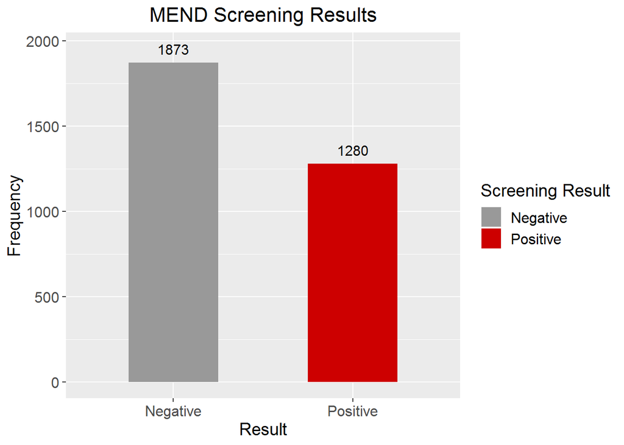

```r
# Create theme for visualizations

custom_plot_theme <- function() {
  theme(plot.title=element_text(hjust=0.5,size=16),axis.text.y = element_text(size=12),axis.text.x = element_text(size=12),
        axis.title.y = element_text(size=14),axis.title.x = element_text(size=14),
        legend.text = element_text(size = 12),legend.title = element_text(size = 14))
}

# Show bar plot of screening result
final_cohort %>% group_by(screening_outcome) %>% count() %>%
  ggplot(aes(x=reorder(screening_outcome,-n),n,fill=screening_outcome)) +
  geom_bar(stat='identity',width=0.5) +
  ggtitle("MEND Screening Results") +
  custom_plot_theme()+
  xlab("Result") +
  ylab("Frequency") +
  scale_fill_manual(values=c("#999999","red3")) +
  geom_text(aes(x = screening_outcome, y = n+80, label = n), colour="black", size = 4) +
  labs(fill="Screening Result")
```

## Examining Previous Encounters

> If patients haven’t had visits to the University of Pennsylvania Health System in the past, information about them may be limited. Over 70% of patients had a prior outpatient encounter, but only 50-60% had previous ED visits and admissions. Because the intervention is working in the inpatient setting, data from previous admissions may be the most relevant.

```r
# Evaluate availability of prior data

all_vars <- final_cohort %>% mutate(PREVIOUS_ED_VISIT_YN=if_else(PREVIOUS_ED_VISIT_YN=="Yes",1,0),
                                            PREVIOUS_ADMISSION_YN=if_else(PREVIOUS_ADMISSION_YN=="Yes",1,0))
variable_summary <- melt(all_vars[c('RANDOM_ENC_ID','screening_outcome','PREVIOUS_OUTPATIENT_VISIT_YN', 'PREVIOUS_ED_VISIT_YN', 'PREVIOUS_ADMISSION_YN',
                                         'ANY_MEDICATION_ORDER_YN')], id=c('RANDOM_ENC_ID','screening_outcome'))

variable_summary %>% group_by(variable,screening_outcome) %>%
  summarize(Freq_Yes=sum(value==1), Prop_Yes = sum(value==1)/n(),
                                         Freq_No = sum(value==0), Prop_No = sum(value==0)/n(),
                                         Freq_Prop_Yes = paste(Freq_Yes," (",round(Prop_Yes*100,2),")",sep=''),
                                         Freq_Prop_No = paste(Freq_No," (",round(Prop_No*100,2),")",sep="")) %>% kable()
```

| variable | screening_outcome | Freq_Yes | Prop_Yes | Freq_No | Prop_No | Freq_Prop_Yes | Freq_Prop_No |
| --- | --- | --- | --- | --- | --- | --- | --- |
| PREVIOUS_OUTPATIENT_VISIT_YN | Negative | 1360 | 0.7261078 | 513 | 0.2738922 | 1360 (72.61) | 513 (27.39) |
| PREVIOUS_OUTPATIENT_VISIT_YN | Positive | 930 | 0.7265625 | 350 | 0.2734375 | 930 (72.66) | 350 (27.34) |
| PREVIOUS_ED_VISIT_YN | Negative | 1000 | 0.5339028 | 873 | 0.4660972 | 1000 (53.39) | 873 (46.61) |
| PREVIOUS_ED_VISIT_YN | Positive | 858 | 0.6703125 | 422 | 0.3296875 | 858 (67.03) | 422 (32.97) |
| PREVIOUS_ADMISSION_YN | Negative | 916 | 0.4890550 | 957 | 0.5109450 | 916 (48.91) | 957 (51.09) |
| PREVIOUS_ADMISSION_YN | Positive | 749 | 0.5851562 | 531 | 0.4148438 | 749 (58.52) | 531 (41.48) |
| ANY_MEDICATION_ORDER_YN | Negative | 1429 | 0.7629471 | 444 | 0.2370529 | 1429 (76.29) | 444 (23.71) |
| ANY_MEDICATION_ORDER_YN | Positive | 1016 | 0.7937500 | 264 | 0.2062500 | 1016 (79.38) | 264 (20.62) |

## Visualizing Geospatial Data

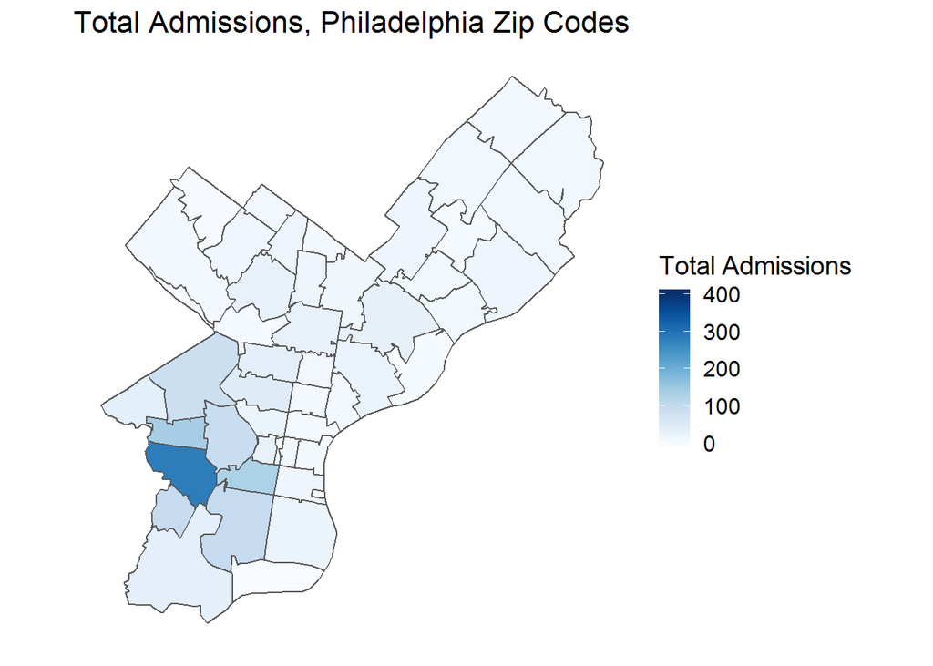

```r
# Admissions/Screening Outcomes by zip code
admissions_zip <- final_cohort %>% group_by(ZIP) %>% summarise(Total_Admissions = n(), Proportion_Positive = mean(if_else(screening_outcome=="Positive",1,0)))

# Install census api key
census_api_key("9bbda6b4cb68c4beb4f7510f920872eba33713c7", install=TRUE, overwrite=TRUE)

# Load variables
vars <- load_variables(dataset = "acs5",  # ACS 5-year estimates
                       year = 2017)  # end year

# View variables
#View(vars)

us_zip <- get_acs(geography = "zcta",         # query data at the tract level
                   year = 2017,                 # end year (these will give us ACS 5-year estimates for 2013-2017)
                   variables = c("B19013_001"),  # Total Population
                   #state = "PA",
                   #county = "Philadelphia",
                   geometry=TRUE
                   )

# Create color palette
yor <- colorRampPalette(brewer.pal(9, "YlOrRd"))
blues <- colorRampPalette(brewer.pal(9, "Blues"))

phila_zip <- us_zip %>% filter(GEOID %in% c("19104","19131","19139","19151", # West Philadelphia
                                "19118","19119","19129","19144", # Upper Northwest
                                "19127","19128", # Roxborough-Manayunk
                                "19120","19126","19138","19141","19150", # Olney-Oak Lane
                                "19132","19133","19140", # Upper North Philadelphia
                                "19121","19122","19123","19130", # Lower North Philadelphia
                                "19125","19134", # Kensington-Port Richmond
                                "19111","19124","19135","19137","19149", # Near Northeast Philadelphia
                                "19114","19115","19116","19136","19152","19154", # Far Northeast
                                "19102","19103","19106","19107","19109", # Center City
                                "19112","19145","19146","19147","19148", # South Philadelphia
                                "19142","19143","19153" # Southwest Philadelphia
                                )
                   )

phila_zip %>% left_join(admissions_zip,by=c("GEOID"="ZIP")) %>%
  mutate(Total_Admissions=if_else(is.na(Total_Admissions),0,as.numeric(Total_Admissions)),
  Proportion_Positive=if_else(is.na(Proportion_Positive),0,Proportion_Positive)) %>%
  ggplot(aes(fill = Total_Admissions)) +
  geom_sf() +
  scale_fill_gradientn(name = "Total Admissions", colors = blues(100), limit=range(0, 400)) +
  ggtitle("Total Admissions, Philadelphia Zip Codes") +
  theme_minimal() +
  theme(axis.line = element_blank(),
        axis.text = element_blank(),
        axis.title = element_blank(),
        panel.grid = element_line(color = "white"),
        legend.key.size = unit(0.6, "cm"),
        legend.text = element_text(size = 12),
        legend.title = element_text(size = 14),
        plot.title = element_text(size=16, hjust=0.5))
```

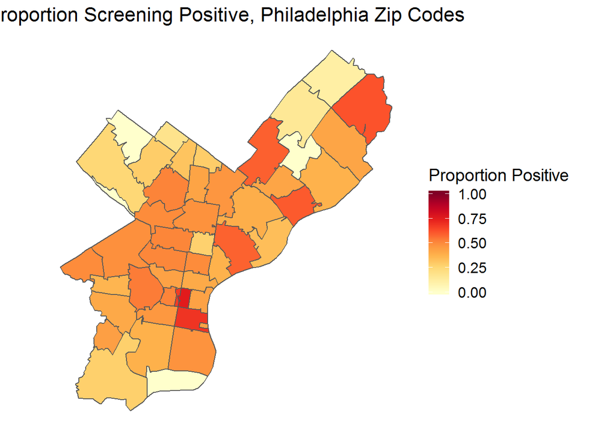

```r
phila_zip %>% left_join(admissions_zip,by=c("GEOID"="ZIP")) %>% mutate(Total_Admissions=if_else(is.na(Total_Admissions),0,as.numeric(Total_Admissions)),
  Proportion_Positive=if_else(is.na(Proportion_Positive),0,Proportion_Positive)) %>%
  ggplot(aes(fill = Proportion_Positive)) +
  geom_sf() +
  scale_fill_gradientn(name = "Proportion Positive", colors = yor(100), limit=range(0, 1)) +
  ggtitle("Proportion Screening Positive, Philadelphia Zip Codes") +
  theme_minimal() +
  theme(axis.line = element_blank(),
        axis.text = element_blank(),
        axis.title = element_blank(),
        panel.grid = element_line(color = "white"),
        legend.key.size = unit(0.6, "cm"),
        legend.text = element_text(size = 12),
        legend.title = element_text(size = 14),
        plot.title = element_text(size=16, hjust=0.5))
```

```r
# Chi-square Test
chisq.test(table(final_cohort$screening_outcome,final_cohort$REGION))
```

[output not shown]

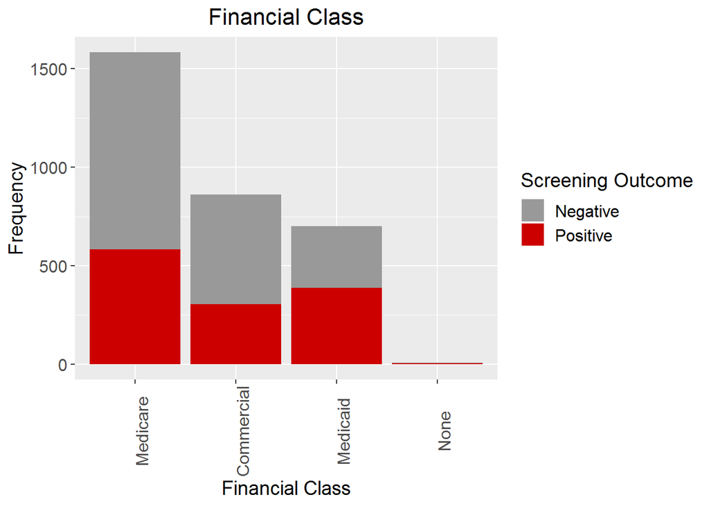

```r
# Potential Predictors
final_cohort %>% mutate(FINANCIAL_CLASS = if_else(FINANCIAL_CLASS=='','None',as.character(FINANCIAL_CLASS))) %>%
  count(FINANCIAL_CLASS, screening_outcome) %>%
  ggplot(aes(x=reorder(FINANCIAL_CLASS,-n),n,fill=factor(screening_outcome,levels=c("Positive","Negative")))) +
  geom_bar(stat='identity',position=position_stack(reverse=TRUE)) +
  custom_plot_theme() +
  theme(axis.text.x = element_text(angle = 90)) +
  ggtitle("Financial Class") +
  xlab("Financial Class") +
  ylab("Frequency") +
  scale_fill_manual(name="Screening Outcome",values=c("red3","#999999"), guide=guide_legend(reverse=TRUE))
```

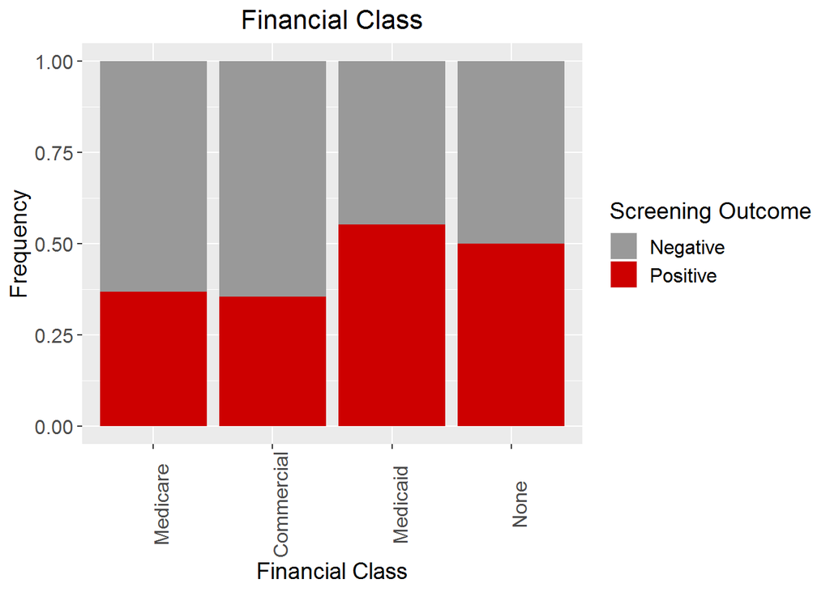

```r
final_cohort %>% mutate(FINANCIAL_CLASS = if_else(FINANCIAL_CLASS=='','None',as.character(FINANCIAL_CLASS))) %>%
  count(FINANCIAL_CLASS, screening_outcome) %>%
  ggplot(aes(x=reorder(FINANCIAL_CLASS,-n),n,fill=factor(screening_outcome,levels=c("Positive","Negative")))) +
  geom_bar(stat='identity',position=position_fill(reverse=TRUE)) +
  custom_plot_theme() +
  theme(axis.text.x = element_text(angle = 90)) +
  ggtitle("Financial Class") +
  xlab("Financial Class") +
  ylab("Frequency") +
  scale_fill_manual(name="Screening Outcome",values=c("red3","#999999"), guide=guide_legend(reverse=TRUE))
```

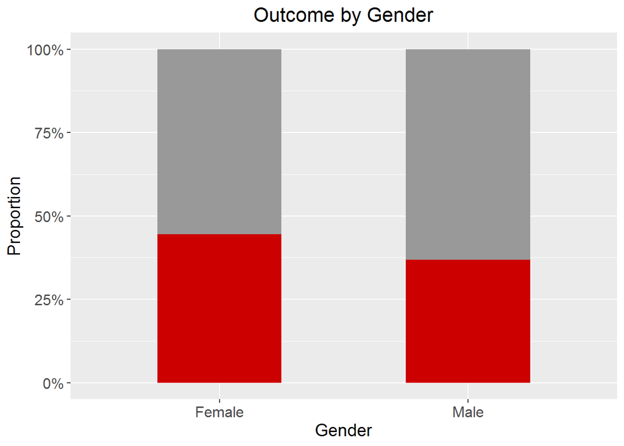

```r
# Gender Bar Plot
final_cohort %>% ggplot(aes(factor(GENDER),fill=factor(screening_outcome,levels=c("Positive","Negative")))) +
  geom_bar(position=position_fill(reverse=TRUE),width=0.5) +
  scale_fill_manual(values=c("red3","#999999"),guide=guide_legend(reverse=TRUE)) +
  scale_y_continuous(labels=scales::percent) +
  ggtitle("Outcome by Gender") +
  custom_plot_theme() +
  theme(legend.position="none") +
  ylab("Proportion") +
  xlab("Gender")
```

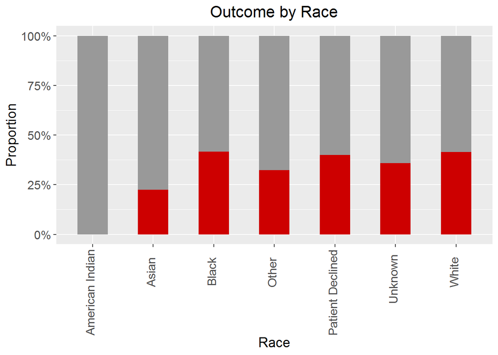

```r
# Race Bar Plot
final_cohort %>% ggplot(aes(factor(RACE),fill=factor(screening_outcome,levels=c("Positive","Negative")))) +
  geom_bar(position=position_fill(reverse=TRUE),width=0.5) +
  scale_fill_manual(values=c("red3","#999999"),guide=guide_legend(reverse=TRUE)) +
  scale_y_continuous(labels=scales::percent) +
  ggtitle("Outcome by Race") +
  custom_plot_theme() +
  theme(axis.text.x = element_text(angle = 90,hjust=0.85,vjust=0.2),legend.position="none") +
  ylab("Proportion") +
  xlab("Race")
```

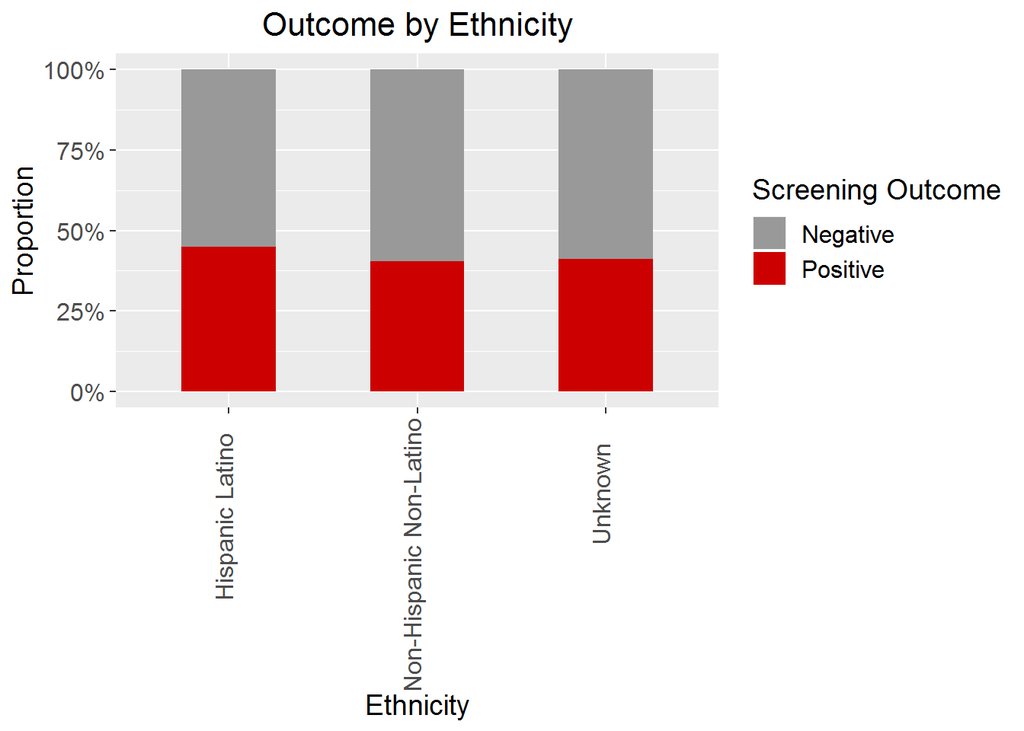

```r
# Ethnicity
final_cohort %>% ggplot(aes(factor(ETHNICITY),fill=factor(screening_outcome,levels=c("Positive","Negative")))) +
  geom_bar(position=position_fill(reverse=TRUE),width=0.5) +
  scale_fill_manual(name="Screening Outcome",values=c("red3","#999999"),guide=guide_legend(reverse=TRUE)) +
  scale_y_continuous(labels=scales::percent) +
  ggtitle("Outcome by Ethnicity") +
  custom_plot_theme() +
  theme(axis.text.x = element_text(angle = 90,hjust=0.85,vjust=0.2)) +
  ylab("Proportion") +
  xlab("Ethnicity")
```

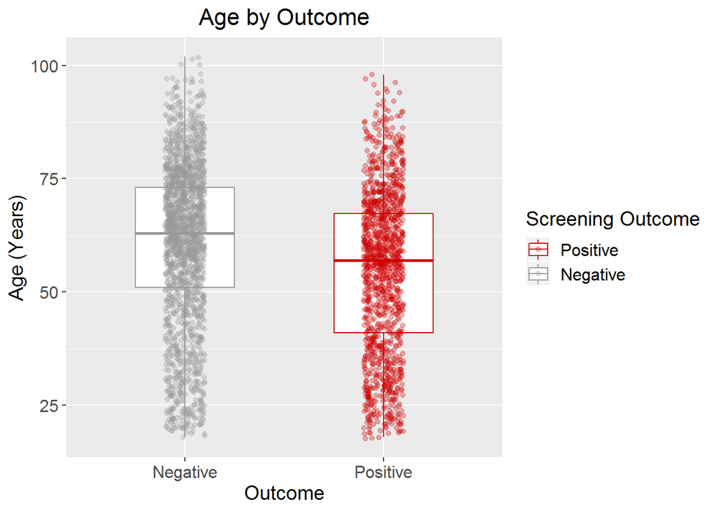

```r
# Boxplot of Age by outcome
final_cohort %>% ggplot(aes(screening_outcome,AGE,color=factor(screening_outcome,levels=c("Positive","Negative")))) +
  geom_boxplot(width=0.5) +
  geom_jitter(width=0.1,alpha=0.3) +
  ggtitle("Age by Outcome") +
  xlab("Outcome") +
  ylab("Age (Years)") +
  scale_color_manual(name="Screening Outcome",values=c("red3","#999999")) +
  custom_plot_theme()
```

```r
t.test(final_cohort$AGE~final_cohort$screening_outcome)
```

```
##
##  Welch Two Sample t-test
##
## data:  final_cohort$AGE by final_cohort$screening_outcome
## t = 9.5944, df = 2749.2, p-value < 2.2e-16
## alternative hypothesis: true difference in means is not equal to 0
## 95 percent confidence interval:
##  4.892170 7.405467
## sample estimates:
## mean in group Negative mean in group Positive
##               60.74960               54.60078
```

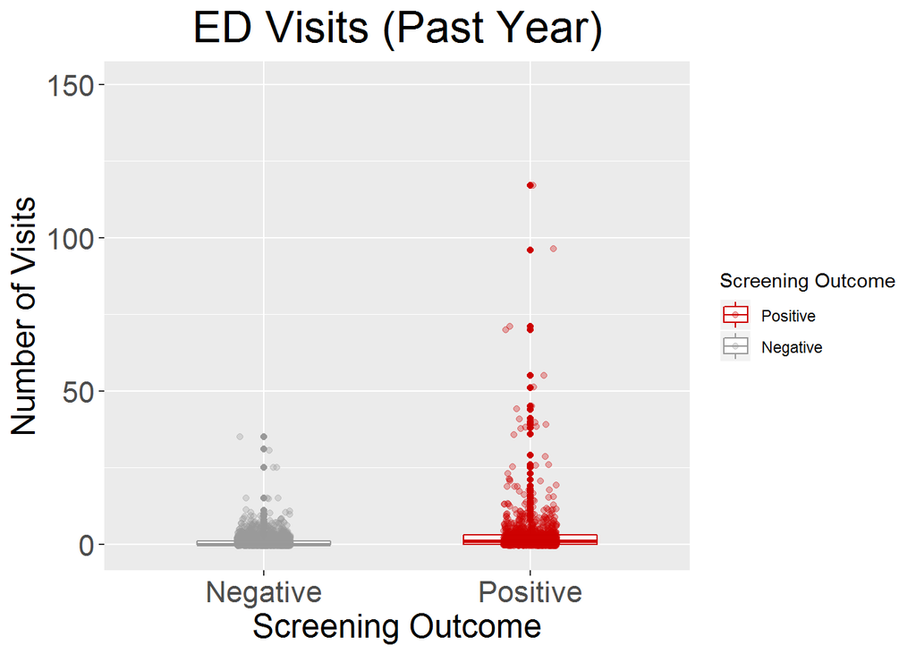

```r
# Boxplot of ED Visits by outcome
final_cohort %>% ggplot(aes(screening_outcome,NUM_ED_VISITS_PAST_YEAR,color=factor(screening_outcome,levels=c("Positive","Negative")))) +
  geom_boxplot(width=0.5) +
  geom_jitter(width=0.1,alpha=0.3) +
  ggtitle("ED Visits (Past Year)") +
  theme(plot.title = element_text(hjust = 0.5,size=24),
        axis.title.y=element_text(size=18),axis.title.x=element_text(size=18),
        axis.text.y=element_text(size=16),axis.text.x=element_text(size=16)) +
  xlab("Screening Outcome") +
  ylab("Number of Visits") +
  ylim(c(-1,150)) +
  scale_color_manual(name="Screening Outcome",values=c("red3","#999999"))
```

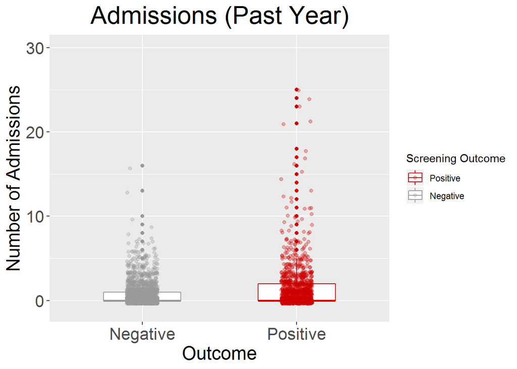

```r
# Boxplot of Admissions by outcome
final_cohort %>% ggplot(aes(screening_outcome,NUM_ADMISSIONS_PAST_YEAR,color=factor(screening_outcome,levels=c("Positive","Negative")))) +
  geom_boxplot(width=0.5) +
  geom_jitter(width=0.1,alpha=0.3) +
  ggtitle("Admissions (Past Year)") +
  theme(plot.title = element_text(hjust = 0.5,size=24),
        axis.title.y=element_text(size=18),axis.title.x=element_text(size=18),
        axis.text.y=element_text(size=16),axis.text.x=element_text(size=16)) +
  xlab("Outcome") +
  ylab("Number of Admissions") +
  ylim(c(-1,30)) +
  scale_color_manual(name="Screening Outcome",values=c("red3","#999999"))
```

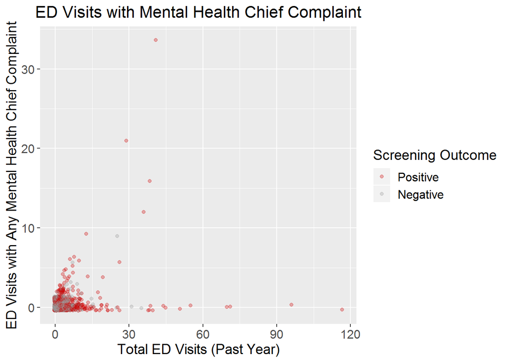

```r
# Total ED Visits by ED Visits with Mental Health Chief Complaint
final_cohort %>% ggplot(aes(NUM_ED_VISITS_PAST_YEAR,ED_VISITS_ANY_MENTAL_HEALTH_CHIEF_COMPLAINTS,
                            color=factor(screening_outcome,levels=c("Positive","Negative")))) +
  geom_jitter(alpha=0.3) +
  ggtitle("ED Visits with Mental Health Chief Complaint") +
  custom_plot_theme() +
  xlab("Total ED Visits (Past Year)") +
  ylab("ED Visits with Any Mental Health Chief Complaint") +
  scale_color_manual(name="Screening Outcome",values=c("red3","#999999"))
```

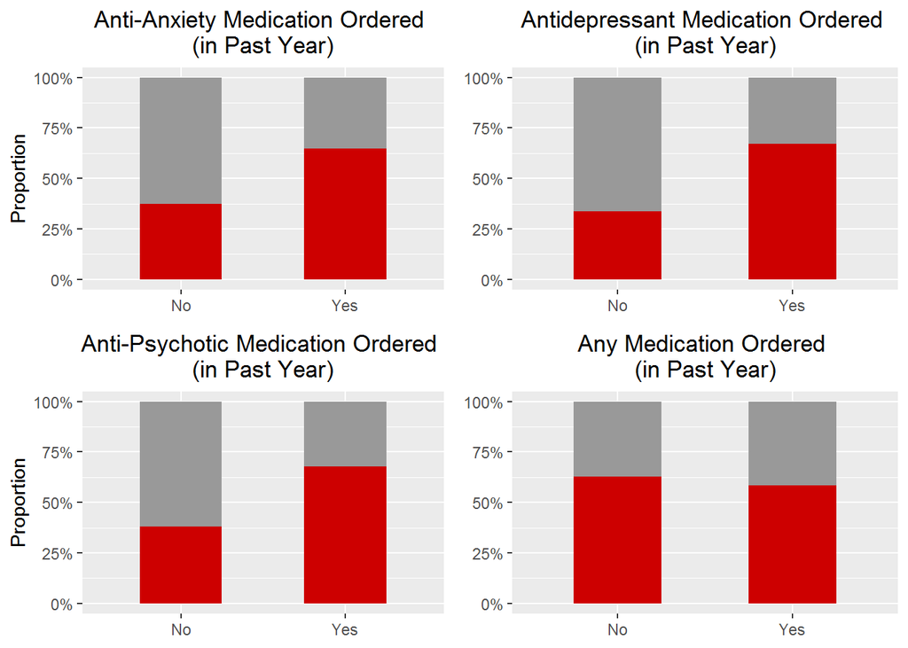

```r
# Previous Medication Orders
med1 <- final_cohort %>% mutate(ANTIANXIETY_YN = factor(ANTIANXIETY_YN,levels=c(0,1),labels=c("No","Yes"))) %>%
  ggplot(aes(ANTIANXIETY_YN,fill=factor(screening_outcome,levels=c("Positive","Negative")))) +
  geom_bar(position=position_fill(reverse=TRUE),width=0.5) +
  scale_fill_manual(name="Screening Outcome",values=c("red3","#999999"),guide=guide_legend(reverse=TRUE)) +
  scale_y_continuous(labels=scales::percent) +
  ggtitle("Anti-Anxiety Medication Ordered \n(in Past Year)") +
  theme(plot.title = element_text(hjust = 0.5),legend.position="none",axis.title.x=element_blank()) +
  ylab("Proportion") +
  xlab("Ordered (Y/N)")

med2 <- final_cohort %>% mutate(ANTIDEPRESSANT_YN = factor(ANTIDEPRESSANT_YN,levels=c(0,1),labels=c("No","Yes"))) %>%
  ggplot(aes(ANTIDEPRESSANT_YN,fill=factor(screening_outcome,levels=c("Positive","Negative")))) +
  geom_bar(position=position_fill(reverse=TRUE),width=0.5) +
  scale_fill_manual(name="Screening Outcome",values=c("red3","#999999"),guide=guide_legend(reverse=TRUE)) +
  scale_y_continuous(labels=scales::percent) +
  ggtitle("Antidepressant Medication Ordered \n(in Past Year)") +
  xlab("Ordered (Y/N)") +
  ylab("Proportion") +
  theme(plot.title = element_text(hjust = 0.5),legend.position="none",axis.title.y=element_blank(),axis.title.x=element_blank())

med3 <- final_cohort %>% mutate(ANTIPSYCHOTIC_YN = factor(ANTIPSYCHOTIC_YN,levels=c(0,1),labels=c("No","Yes"))) %>%
  ggplot(aes(ANTIPSYCHOTIC_YN,fill=factor(screening_outcome,levels=c("Positive","Negative")))) +
  geom_bar(position=position_fill(reverse=TRUE),width=0.5) +
  scale_fill_manual(name="Screening Outcome",values=c("red3","#999999"),guide=guide_legend(reverse=TRUE)) +
  scale_y_continuous(labels=scales::percent) +
  ggtitle("Anti-Psychotic Medication Ordered \n(in Past Year)") +
  theme(plot.title = element_text(hjust = 0.5),legend.position="none",axis.title.x=element_blank()) +
  ylab("Proportion") +
  xlab("Ordered (Y/N)")

med4 <- final_cohort %>% mutate(ANY_MEDICATION_ORDER_YN = factor(ANY_MEDICATION_ORDER_YN,levels=c(0,1),labels=c("No","Yes"))) %>%
  ggplot(aes(ANY_MEDICATION_ORDER_YN,fill=screening_outcome)) +
  geom_bar(position=position_fill(reverse=TRUE),width=0.5) +
  scale_fill_manual(name="Screening Outcome",values=c("red3","#999999"),guide=guide_legend(reverse=TRUE)) +
  scale_y_continuous(labels=scales::percent) +
  ggtitle("Any Medication Ordered \n(in Past Year)") +
  theme(plot.title = element_text(hjust = 0.5),legend.position="none",axis.title.y=element_blank(),axis.title.x=element_blank()) +
  ylab("Proportion") +
  xlab("Ordered (Y/N)")

grid.arrange(med1,med2,med3,med4,nrow=2)
```

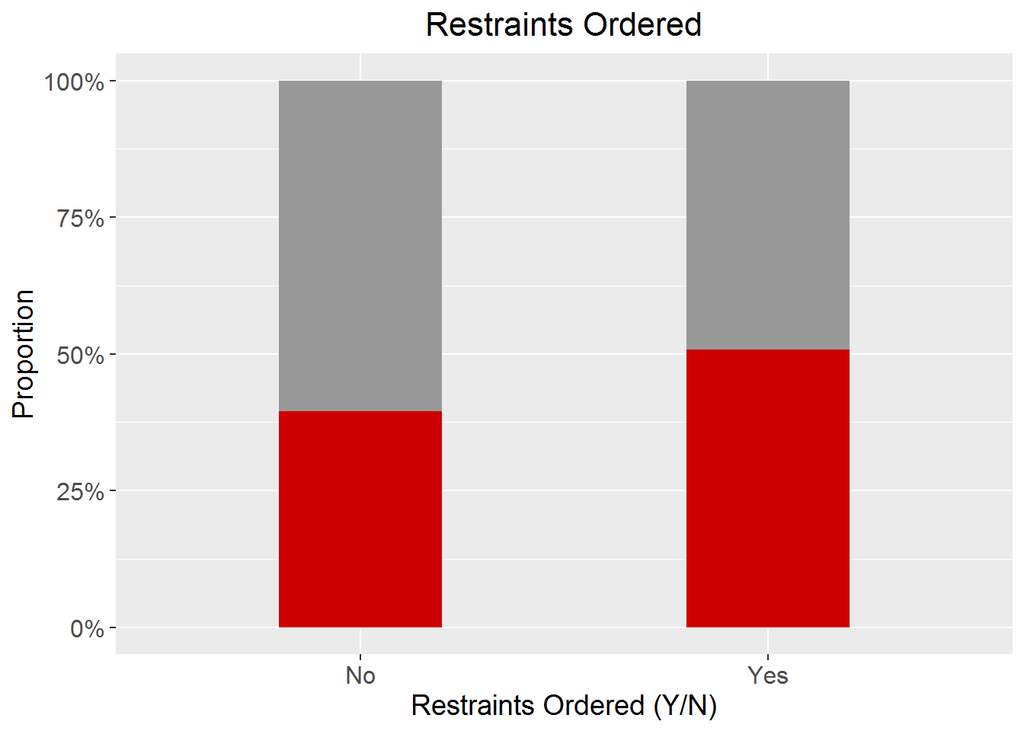

```r
#Restraints
final_cohort %>% mutate(RESTRAINTS_ORDERED_YN = factor(RESTRAINTS_ORDERED_YN,levels=c(0,1),labels=c("No","Yes"))) %>%
  ggplot(aes(RESTRAINTS_ORDERED_YN,fill=factor(screening_outcome,levels=c("Positive","Negative")))) +
  geom_bar(position=position_fill(reverse=TRUE),width=0.4) +
  scale_fill_manual(name="Screening Outcome",values=c("red3","#999999"),guide=guide_legend(reverse=TRUE)) +
  scale_y_continuous(labels=scales::percent) +
  ggtitle("Restraints Ordered") +
  custom_plot_theme() +
  theme(legend.position="none") +
  ylab("Proportion") +
  xlab("Restraints Ordered (Y/N)")
```

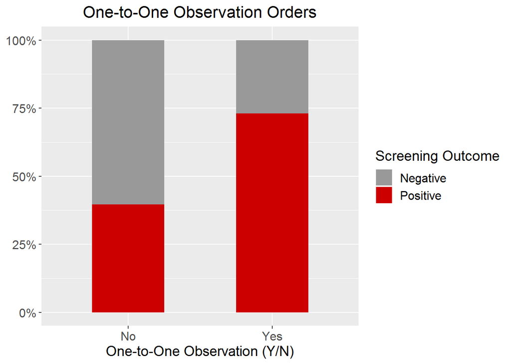

```r
# One-to-One Obs
final_cohort%>% mutate(ONE_TO_ONE_OBSERVATION_ORDERED_YN = factor(ONE_TO_ONE_OBSERVATION_ORDERED_YN,levels=c(0,1),labels=c("No","Yes"))) %>%
  ggplot(aes(ONE_TO_ONE_OBSERVATION_ORDERED_YN,fill=factor(screening_outcome,levels=c("Positive","Negative")))) +
  geom_bar(position=position_fill(reverse=TRUE),width=0.5) +
  scale_fill_manual(name="Screening Outcome",values=c("red3","#999999"),guide=guide_legend(reverse=TRUE)) +
  scale_y_continuous(labels=scales::percent) +
  ggtitle("One-to-One Observation Orders") +
  custom_plot_theme() +
  theme(axis.title.y=element_blank()) +
  ylab("Proportion") +
  xlab("One-to-One Observation (Y/N)")
```

> The PHQ-9 assessment for depression was significantly associated with being marked as eligible for the intervention. The GAD-7 score for anxiety was not significantly different between groups, though not as many patients had GAD-7 scores.

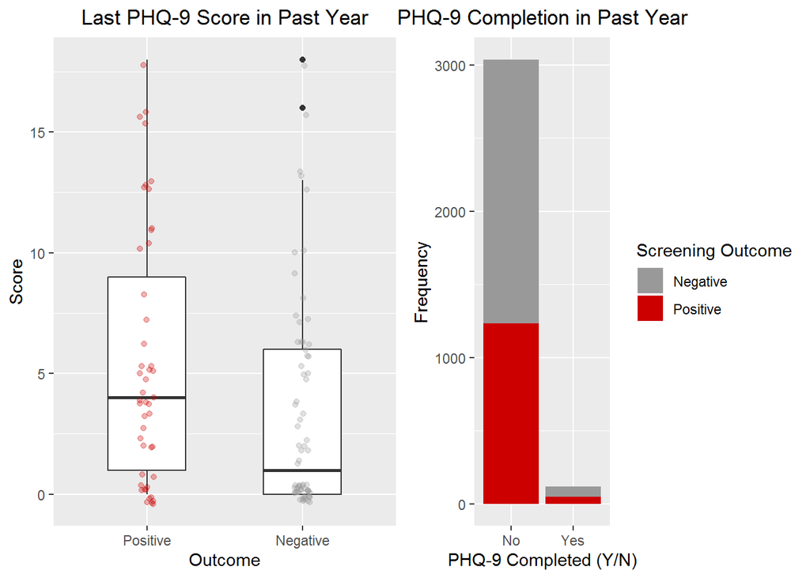

```r
# Last PHQ-9
phq9_1 <- final_cohort %>% mutate(PHQ9_YN=factor(if_else(is.na(LAST_PHQ9_SCORE),0,1),levels=c(0,1),labels=c("No","Yes"))) %>%
  ggplot(aes(PHQ9_YN,fill=factor(screening_outcome,levels=c("Positive","Negative")))) +
  geom_bar(position=position_stack(reverse=TRUE)) +
  scale_fill_manual(name="Screening Outcome",values=c("red3","#999999"),guide=guide_legend(reverse=TRUE)) +
  ggtitle("PHQ-9 Completion in Past Year") +
  theme(plot.title = element_text(hjust = 0.5)) +
  xlab("PHQ-9 Completed (Y/N)") +
  ylab("Frequency")

phq9_2 <- final_cohort %>% filter(!is.na(LAST_PHQ9_SCORE)) %>%
  ggplot(aes(factor(screening_outcome,levels=c("Positive","Negative")),LAST_PHQ9_SCORE)) +
  geom_boxplot(width=0.5) +
  geom_jitter(width=0.05,alpha=0.3,aes(col=factor(screening_outcome,levels=c("Positive","Negative")))) +
  #scale_fill_manual(values=c("red3","#999999"),guide=guide_legend(reverse=TRUE)) +
  scale_color_manual(values = c("red3","#999999")) +
  ggtitle("Last PHQ-9 Score in Past Year") +
  theme(plot.title = element_text(hjust = 0.5),legend.position="none") +
  xlab("Outcome") +
  ylab("Score")

grid.arrange(phq9_2,phq9_1,ncol=2)
```

```r
t.test(final_cohort$LAST_PHQ9_SCORE~final_cohort$screening_outcome)
```

```
##
##  Welch Two Sample t-test
##
## data:  final_cohort$LAST_PHQ9_SCORE by final_cohort$screening_outcome
## t = -2.3379, df = 86.874, p-value = 0.02169
## alternative hypothesis: true difference in means is not equal to 0
## 95 percent confidence interval:
##  -4.0067565 -0.3244183
## sample estimates:
## mean in group Negative mean in group Positive
##               3.217391               5.382979
```

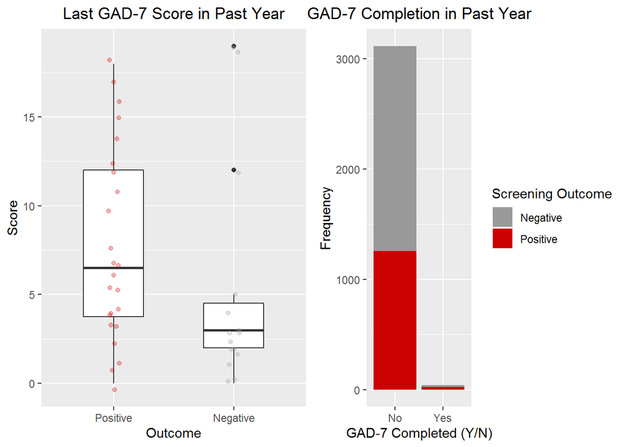

```r
# Last GAD-7
gad7_1 <- final_cohort %>% mutate(GAD_YN=factor(if_else(is.na(LAST_GAD_7_SCORE),0,1),levels=c(0,1),labels=c("No","Yes"))) %>%
  ggplot(aes(GAD_YN,fill=factor(screening_outcome,levels=c("Positive","Negative")))) +
  geom_bar(position=position_stack(reverse=TRUE)) +
  scale_fill_manual(name="Screening Outcome",values=c("red3","#999999"),guide=guide_legend(reverse=TRUE)) +
  ggtitle("GAD-7 Completion in Past Year") +
  theme(plot.title = element_text(hjust = 0.5)) +
  xlab("GAD-7 Completed (Y/N)") +
  ylab("Frequency")

gad7_2 <- final_cohort %>% filter(!is.na(LAST_GAD_7_SCORE)) %>%
  ggplot(aes(factor(screening_outcome,levels=c("Positive","Negative")),LAST_GAD_7_SCORE)) +
  geom_boxplot(width=0.5) +
  geom_jitter(width=0.05,alpha=0.3,aes(col=factor(screening_outcome,levels=c("Positive","Negative")))) +
  scale_color_manual(values = c("red3","#999999")) +
  ggtitle("Last GAD-7 Score in Past Year") +
  theme(plot.title = element_text(hjust = 0.5),legend.position="none") +
  xlab("Outcome") +
  ylab("Score")

grid.arrange(gad7_2,gad7_1,ncol=2)
```

```r
t.test(final_cohort$LAST_GAD_7_SCORE~final_cohort$screening_outcome)
```

```
##
##  Welch Two Sample t-test
##
## data:  final_cohort$LAST_GAD_7_SCORE by final_cohort$screening_outcome
## t = -1.3036, df = 26.767, p-value = 0.2035
## alternative hypothesis: true difference in means is not equal to 0
## 95 percent confidence interval:
##  -6.629583  1.479583
## sample estimates:
## mean in group Negative mean in group Positive
##               5.133333               7.708333
```

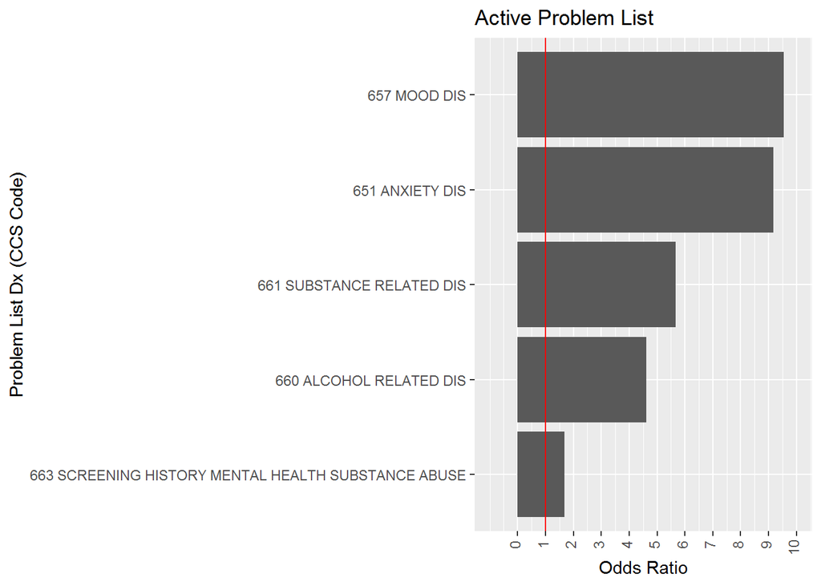

```r
# Odds Ratio Plots
tall <- melt(final_cohort[,c('RANDOM_ENC_ID','screening_outcome','PL_CCS_650_ADJUSTMENT_DISORDERS','PL_CCS_651_ANXIETY_DISORDERS','PL_CCS_652_ATTENTION_DEFICIT_CONDUCT_DISRUPTIVE_BEHAVIOR_DISORDERS','PL_CCS_653_DELIRIUM_DEMENTIA_AMNESTIC_OTH_COGN_DISORDERS','PL_CCS_654_DEVELOPMENTAL_DISORDERS','PL_CCS_655_DISORDERS_USUALLY_DIAGNOSED_INF_CHILD_ADOL','PL_CCS_656_IMPULSE_CONTROL_DISORDERS','PL_CCS_657_MOOD_DISORDERS','PL_CCS_658_PERSONALITY_DISORDERS','PL_CCS_659_SCHIZOPHRENIA_OTHER_PSYCHOTIC_DISORDERS','PL_CCS_660_ALCOHOL_RELATED_DISORDERS','PL_CCS_661_SUBSTANCE_RELATED_DISORDERS','PL_CCS_662_SUICIDE_INTENTIONAL_INJURY','PL_CCS_663_SCREENING_HISTORY_MENTAL_HEALTH_SUBSTANCE_ABUSE','PL_CCS_670_MISC_MENTAL_HEALTH_DISORDERS')], id=c('RANDOM_ENC_ID','screening_outcome'))

tall %>% mutate(variable=gsub('PL CCS ','',gsub("_"," ",variable))) %>%
  mutate(variable=gsub('DISORDERS','DIS',variable)) %>%
  group_by(variable) %>% summarize(prevalence=sum(value==1)/n(),prop=sum(screening_outcome=="Positive"&value==1)/sum(value==1),
                                   odds_ratio=sum(screening_outcome=="Positive"&value==1)*sum(screening_outcome=="Negative"&value==0)/
                                     (sum(screening_outcome=="Positive"&value==0)*sum(screening_outcome=="Negative"&value==1))) %>% filter(prevalence>=0.02) %>%
  ggplot(aes(reorder(variable,odds_ratio),y=odds_ratio)) +
  geom_bar(stat='identity') +
  theme(axis.text.x = element_text(angle = 90,hjust=0.85,vjust=0.2)) +
  ggtitle("Active Problem List") +
  xlab("Problem List Dx (CCS Code)") +
  ylab("Odds Ratio") +
  geom_hline(yintercept=1,color='red') +
  scale_y_continuous(breaks=c(0:10),limits=c(-1, 10)) +
  coord_flip()
```

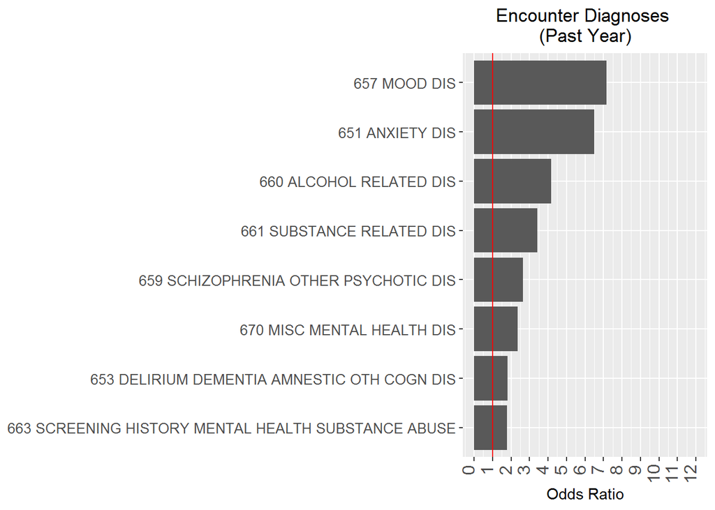

```r
encdx <- melt(final_cohort[,c('RANDOM_ENC_ID','screening_outcome','ENC_DX_CCS_650_ADJUSTMENT_DISORDERS','ENC_DX_CCS_651_ANXIETY_DISORDERS','ENC_DX_CCS_652_ATTENTION_DEFICIT_CONDUCT_DISRUPTIVE_BEHAVIOR_DISORDERS','ENC_DX_CCS_653_DELIRIUM_DEMENTIA_AMNESTIC_OTH_COGN_DISORDERS','ENC_DX_CCS_654_DEVELOPMENTAL_DISORDERS','ENC_DX_CCS_655_DISORDERS_USUALLY_DIAGNOSED_INF_CHILD_ADOL','ENC_DX_CCS_656_IMPULSE_CONTROL_DISORDERS','ENC_DX_CCS_657_MOOD_DISORDERS','ENC_DX_CCS_658_PERSONALITY_DISORDERS','ENC_DX_CCS_659_SCHIZOPHRENIA_OTHER_PSYCHOTIC_DISORDERS','ENC_DX_CCS_660_ALCOHOL_RELATED_DISORDERS','ENC_DX_CCS_661_SUBSTANCE_RELATED_DISORDERS','ENC_DX_CCS_662_SUICIDE_INTENTIONAL_INJURY','ENC_DX_CCS_663_SCREENING_HISTORY_MENTAL_HEALTH_SUBSTANCE_ABUSE','ENC_DX_CCS_670_MISC_MENTAL_HEALTH_DISORDERS')], id=c('RANDOM_ENC_ID','screening_outcome'))

encdx %>% mutate(variable=gsub('ENC DX CCS ','',gsub("_"," ",variable))) %>%
  mutate(variable=gsub('DISORDERS','DIS',variable)) %>%
  group_by(variable) %>% summarize(prevalence=sum(value==1)/n(),prop=sum(screening_outcome==1&value==1)/sum(value==1),
                                   odds_ratio=sum(screening_outcome=="Positive"&value==1)*sum(screening_outcome=="Negative"&value==0)/
                                     (sum(screening_outcome=="Positive"&value==0)*sum(screening_outcome=="Negative"&value==1))) %>%
  filter(!is.na(odds_ratio)) %>% filter(prevalence>=0.02) %>%
  ggplot(aes(reorder(variable,odds_ratio),y=odds_ratio)) +
  geom_bar(stat='identity') +
  theme(plot.title=element_text(hjust=0.5), axis.text.x = element_text(angle = 90,hjust=0.85,vjust=0,size=12),
        axis.title.y=element_blank(),axis.text.y=element_text(size=10)) +
  ggtitle("Encounter Diagnoses \n(Past Year)") +
  xlab("Encounter Dx (CCS Code)") +
  ylab("Odds Ratio") +
  geom_hline(yintercept=1,color='red') +
  scale_y_continuous(breaks=c(0:12),limits=c(0, 12)) +
  coord_flip()
```

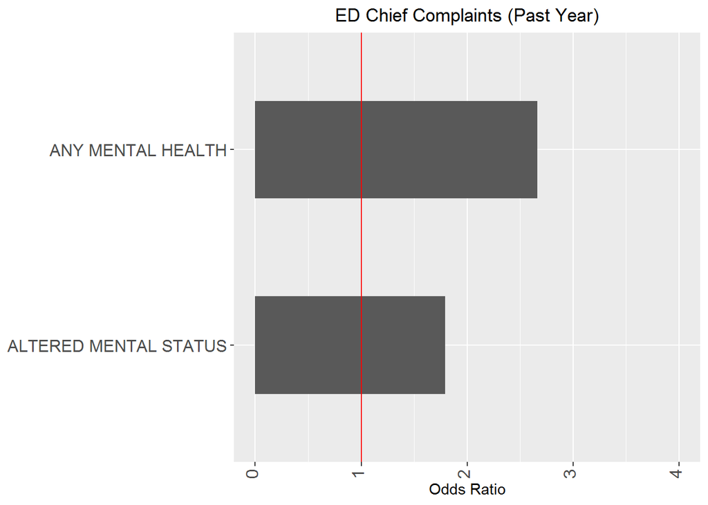

```r
edcc <- melt(final_cohort[,c('RANDOM_ENC_ID','screening_outcome','ED_VISITS_ANY_MENTAL_HEALTH_CHIEF_COMPLAINTS','ED_VISITS_ALTERED_MENTAL_STATUS_CHIEF_COMPLAINTS','ED_VISITS_ALCOHOL_INTOXICATION_CHIEF_COMPLAINTS','ED_VISITS_SUICIDAL_CHIEF_COMPLAINTS','ED_VISITS_PSYCH_EVAL_CHIEF_COMPLAINTS','ED_VISITS_ALCOHOL_PROBLEM_CHIEF_COMPLAINTS','ED_VISITS_WITHDRAWAL_CHIEF_COMPLAINTS','ED_VISITS_DETOX_CHIEF_COMPLAINTS','ED_VISITS_DRUG_OVERDOSE_CHIEF_COMPLAINTS','ED_VISITS_ADDICTION_PROBLEM_CHIEF_COMPLAINTS','ED_VISITS_NEUROLOGIC_PROBLEM_CHIEF_COMPLAINTS','ED_VISITS_ANXIETY_CHIEF_COMPLAINTS','ED_VISITS_HOMICIDAL_CHIEF_COMPLAINTS','ED_VISITS_DRUG_PROBLEM_CHIEF_COMPLAINTS','ED_VISITS_SUICIDE_ATTEMPT_CHIEF_COMPLAINTS','ED_VISITS_MANIC_BEHAVIOR_CHIEF_COMPLAINTS','ED_VISITS_PARANOIA_CHIEF_COMPLAINTS','ED_VISITS_PANIC_ATTACK_CHIEF_COMPLAINTS','ED_VISITS_ANOREXIA_CHIEF_COMPLAINTS','ED_VISITS_DELUSIONAL_CHIEF_COMPLAINTS','ED_VISITS_MENTAL_HEALTH_PROBLEM_CHIEF_COMPLAINTS')], id=c('RANDOM_ENC_ID','screening_outcome'))

edcc %>% mutate(variable=gsub(' CHIEF COMPLAINTS','',gsub('ED VISITS ','',gsub("_"," ",variable)))) %>%
  mutate(value=if_else(value>=1,1,0)) %>%
  group_by(variable) %>% summarize(prevalence=sum(value==1)/n(),prop=sum(screening_outcome=="Positive"&value==1)/sum(value==1),
                                   odds_ratio=sum(screening_outcome=="Positive"&value==1)*sum(screening_outcome=="Negative"&value==0)/
                                     (sum(screening_outcome=="Positive"&value==0)*sum(screening_outcome=="Negative"&value==1))) %>%
  filter(prevalence>=0.02) %>%
  ggplot(aes(reorder(variable,odds_ratio),y=odds_ratio)) +
  geom_bar(stat='identity',width=0.5) +
  theme(plot.title=element_text(hjust=0.5),axis.text.x = element_text(angle = 90,hjust=0.85,vjust=0.2,size=12),
        axis.title.y=element_blank(),axis.text.y=element_text(size=12)) +
  ggtitle("ED Chief Complaints (Past Year)") +
  xlab("Chief Complaint") +
  ylab("Odds Ratio") +
  geom_hline(yintercept=1,color='red') +
  scale_y_continuous(breaks=c(0:4),limits=c(0, 4)) +
  coord_flip()
```

## Logistic regression

> A logistic regression model was used to identify individual features significantly associated with being screened as eligible. After performing the bivariate analyses, significant features (after accounting for multiple testing with a Bonferroni correction) were included in a multivariable logistic regression model.

```r
# Create Analytic Dataset Limited to Features of Interest
analytic <- final_cohort %>% ungroup() %>%
  dplyr::select(screening_outcome,AGE,GENDER,RACE,ETHNICITY,FINANCIAL_CLASS,REGION,SOI_SCORE,ROM_SCORE,ADMIT_SOURCE,PATIENT_CLASS,
         RESTRAINTS_ORDERED_YN,ONE_TO_ONE_OBSERVATION_ORDERED_YN,ANY_OBSERVATION_ORDERED_YN,INPATIENT_PSYCH_CONSULT_YN,ANTIANXIETY_YN,
         ANTIDEPRESSANT_YN,ANTIPSYCHOTIC_YN,ANY_MEDICATION_ORDER_YN,BEHAVIORAL_HEALTH_CONSULT_YN,PSYCHIATRY_CONSULT_YN,
         PSYCHOLOGY_CONSULT_YN,PL_CCS_651_ANXIETY_DISORDERS,PL_CCS_657_MOOD_DISORDERS,
         PL_CCS_660_ALCOHOL_RELATED_DISORDERS,PL_CCS_661_SUBSTANCE_RELATED_DISORDERS,
         PL_CCS_663_SCREENING_HISTORY_MENTAL_HEALTH_SUBSTANCE_ABUSE,
         ENC_DX_CCS_651_ANXIETY_DISORDERS,ENC_DX_CCS_653_DELIRIUM_DEMENTIA_AMNESTIC_OTH_COGN_DISORDERS,
         ENC_DX_CCS_657_MOOD_DISORDERS,ENC_DX_CCS_659_SCHIZOPHRENIA_OTHER_PSYCHOTIC_DISORDERS,
         ENC_DX_CCS_660_ALCOHOL_RELATED_DISORDERS,ENC_DX_CCS_661_SUBSTANCE_RELATED_DISORDERS,
         ENC_DX_CCS_663_SCREENING_HISTORY_MENTAL_HEALTH_SUBSTANCE_ABUSE,ENC_DX_CCS_670_MISC_MENTAL_HEALTH_DISORDERS,PREVIOUS_ED_VISIT_YN,
         NUM_ED_VISITS_PAST_YEAR,ED_VISITS_ANY_MENTAL_HEALTH_CHIEF_COMPLAINTS,ED_VISITS_ALTERED_MENTAL_STATUS_CHIEF_COMPLAINTS,
         PREVIOUS_ADMISSION_YN,NUM_ADMISSIONS_PAST_YEAR,LAST_PHQ2_SCORE,LAST_PHQ9_SCORE,LAST_GAD_7_SCORE,
         UPHS_RISK_SCORE)

# Identify significant features using logistic regression (bivariate analyses)
results <- data.frame()

for(var in colnames(analytic[c(2:45)])){
  bivariate <- analytic %>% dplyr::select(screening_outcome,var)
  logistic_model <- glm(screening_outcome~.,data=bivariate,family=binomial())
  OR <- exp(coef(logistic_model))
  CI <- confint(logistic_model)
  pval <- as.numeric(coef(summary(logistic_model))[2,'Pr(>|z|)'])
  results <- rbind(results,data.frame(var=var,OR=OR,CI=CI,pval=pval))
}

results %>% filter(pval<0.05/44) %>% arrange(pval) %>% kable()
```

| var | OR | CI.2.5.. | CI.97.5.. | pval |
| --- | --- | --- | --- | --- |
| ANTIDEPRESSANT_YN | 0.5099218 | -0.7565849 | -0.5911521 | 0.0000000 |
| ANTIDEPRESSANT_YN | 4.0342318 | 1.2116137 | 1.5806770 | 0.0000000 |
| PL_CCS_657_MOOD_DISORDERS | 0.5543359 | -0.6671655 | -0.5133695 | 0.0000000 |
| PL_CCS_657_MOOD_DISORDERS | 9.5503786 | 1.9565906 | 2.5757772 | 0.0000000 |
| INPATIENT_PSYCH_CONSULT_YN | 0.5561002 | -0.6636115 | -0.5105597 | 0.0000000 |
| INPATIENT_PSYCH_CONSULT_YN | 12.5876592 | 2.1930619 | 2.9007699 | 0.0000000 |
| ENC_DX_CCS_657_MOOD_DISORDERS | 0.5584488 | -0.6599494 | -0.5057973 | 0.0000000 |
| ENC_DX_CCS_657_MOOD_DISORDERS | 7.1626984 | 1.6983471 | 2.2525418 | 0.0000000 |
| PSYCHIATRY_CONSULT_YN | 0.5642428 | -0.6488573 | -0.4962257 | 0.0000000 |
| PSYCHIATRY_CONSULT_YN | 9.9892530 | 1.9825425 | 2.6432442 | 0.0000000 |
| PL_CCS_651_ANXIETY_DISORDERS | 0.5839695 | -0.6135398 | -0.4627716 | 0.0000000 |
| PL_CCS_651_ANXIETY_DISORDERS | 9.1768058 | 1.8784469 | 2.5805013 | 0.0000000 |
| ENC_DX_CCS_651_ANXIETY_DISORDERS | 0.5853524 | -0.6114917 | -0.4600911 | 0.0000000 |
| ENC_DX_CCS_651_ANXIETY_DISORDERS | 6.5038042 | 1.5782689 | 2.1821133 | 0.0000000 |
| ENC_DX_CCS_661_SUBSTANCE_RELATED_DISORDERS | 0.5854358 | -0.6129032 | -0.4584152 | 0.0000000 |
| ENC_DX_CCS_661_SUBSTANCE_RELATED_DISORDERS | 3.4294999 | 1.0095842 | 1.4597143 | 0.0000000 |
| ANTIANXIETY_YN | 0.5956347 | -0.5952697 | -0.4414860 | 0.0000000 |
| ANTIANXIETY_YN | 3.0906680 | 0.9047702 | 1.3559903 | 0.0000000 |
| PL_CCS_661_SUBSTANCE_RELATED_DISORDERS | 0.6187875 | -0.5543024 | -0.4061158 | 0.0000000 |
| PL_CCS_661_SUBSTANCE_RELATED_DISORDERS | 5.6562224 | 1.3914851 | 2.0949421 | 0.0000000 |
| UPHS_RISK_SCORE | 0.4107323 | -1.0276879 | -0.7535702 | 0.0000000 |
| UPHS_RISK_SCORE | 1.1758339 | 0.1287825 | 0.1955209 | 0.0000000 |
| AGE | 2.0913511 | 0.4948442 | 0.9821209 | 0.0000000 |
| AGE | 0.9808127 | -0.0234525 | -0.0153277 | 0.0000000 |
| ANTIPSYCHOTIC_YN | 0.6134454 | -0.5641342 | -0.4136467 | 0.0000000 |
| ANTIPSYCHOTIC_YN | 3.4269925 | 0.9701765 | 1.5002643 | 0.0000000 |
| NUM_ED_VISITS_PAST_YEAR | 0.5477261 | -0.6868666 | -0.5179466 | 0.0000000 |
| NUM_ED_VISITS_PAST_YEAR | 1.1530864 | 0.1121787 | 0.1743844 | 0.0000000 |
| NUM_ADMISSIONS_PAST_YEAR | 0.5712779 | -0.6435049 | -0.4769792 | 0.0000000 |
| NUM_ADMISSIONS_PAST_YEAR | 1.1999063 | 0.1387455 | 0.2275940 | 0.0000000 |
| ENC_DX_CCS_660_ALCOHOL_RELATED_DISORDERS | 0.6371585 | -0.5243868 | -0.3774861 | 0.0000000 |
| ENC_DX_CCS_660_ALCOHOL_RELATED_DISORDERS | 4.1609159 | 1.0753798 | 1.7939581 | 0.0000000 |
| FINANCIAL_CLASS | 0.5503597 | -0.7376938 | -0.4585581 | 0.0000000 |
| FINANCIAL_CLASS | 2.2465702 | 0.6058942 | 1.0142133 | 0.0000000 |
| FINANCIAL_CLASS | 1.0593072 | -0.1148688 | 0.2310069 | 0.0000000 |
| FINANCIAL_CLASS | 1.8169935 | -0.8510935 | 2.0454749 | 0.0000000 |
| PREVIOUS_ED_VISIT_YN | 0.4833906 | -0.8439533 | -0.6114778 | 0.0000000 |
| PREVIOUS_ED_VISIT_YN | 1.7749621 | 0.4264791 | 0.7219701 | 0.0000000 |
| ED_VISITS_ANY_MENTAL_HEALTH_CHIEF_COMPLAINTS | 0.6291490 | -0.5381767 | -0.3890391 | 0.0000000 |
| ED_VISITS_ANY_MENTAL_HEALTH_CHIEF_COMPLAINTS | 1.8700195 | 0.4519243 | 0.8130226 | 0.0000000 |
| PL_CCS_660_ALCOHOL_RELATED_DISORDERS | 0.6507851 | -0.5024045 | -0.3571199 | 0.0000000 |
| PL_CCS_660_ALCOHOL_RELATED_DISORDERS | 4.6098170 | 1.0925980 | 1.9959538 | 0.0000000 |
| ANY_OBSERVATION_ORDERED_YN | 0.6450905 | -0.5118725 | -0.3652439 | 0.0000000 |
| ANY_OBSERVATION_ORDERED_YN | 3.2243537 | 0.8311626 | 1.5230769 | 0.0000000 |
| BEHAVIORAL_HEALTH_CONSULT_YN | 0.6569422 | -0.4926976 | -0.3479827 | 0.0000000 |
| BEHAVIORAL_HEALTH_CONSULT_YN | 4.4282297 | 1.0145382 | 1.9990808 | 0.0000000 |
| ONE_TO_ONE_OBSERVATION_ORDERED_YN | 0.6571120 | -0.4924728 | -0.3476909 | 0.0000000 |
| ONE_TO_ONE_OBSERVATION_ORDERED_YN | 4.1215706 | 0.9568313 | 1.9087278 | 0.0000000 |
| ENC_DX_CCS_663_SCREENING_HISTORY_MENTAL_HEALTH_SUBSTANCE_ABUSE | 0.6259080 | -0.5465145 | -0.3910534 | 0.0000000 |
| ENC_DX_CCS_663_SCREENING_HISTORY_MENTAL_HEALTH_SUBSTANCE_ABUSE | 1.7784118 | 0.3783266 | 0.7736855 | 0.0000000 |
| PREVIOUS_ADMISSION_YN | 0.5548589 | -0.6956634 | -0.4834948 | 0.0000001 |
| PREVIOUS_ADMISSION_YN | 1.4736819 | 0.2445437 | 0.5314309 | 0.0000001 |
| ENC_DX_CCS_670_MISC_MENTAL_HEALTH_DISORDERS | 0.6582418 | -0.4912937 | -0.3454382 | 0.0000021 |
| ENC_DX_CCS_670_MISC_MENTAL_HEALTH_DISORDERS | 2.3504583 | 0.5048527 | 1.2126040 | 0.0000021 |
| ENC_DX_CCS_659_SCHIZOPHRENIA_OTHER_PSYCHOTIC_DISORDERS | 0.6641304 | -0.4817890 | -0.3371170 | 0.0000108 |
| ENC_DX_CCS_659_SCHIZOPHRENIA_OTHER_PSYCHOTIC_DISORDERS | 2.6464316 | 0.5463430 | 1.4164540 | 0.0000108 |
| PATIENT_CLASS | 0.1587302 | -2.5695333 | -1.2205641 | 0.0000150 |
| PATIENT_CLASS | 4.4018089 | 0.8574863 | 2.2142963 | 0.0000150 |
| PATIENT_CLASS | 0.0000081 | NA | 4.1178809 | 0.0000150 |
| PATIENT_CLASS | 6.6937500 | 1.1080990 | 2.7669458 | 0.0000150 |
| PATIENT_CLASS | 0.0000081 | NA | 97.3455123 | 0.0000150 |
| GENDER | 0.8000000 | -0.3236025 | -0.1230575 | 0.0000159 |
| GENDER | 0.7305035 | -0.4567620 | -0.1715517 | 0.0000159 |
| ED_VISITS_ALTERED_MENTAL_STATUS_CHIEF_COMPLAINTS | 0.6572649 | -0.4932742 | -0.3464390 | 0.0000209 |
| ED_VISITS_ALTERED_MENTAL_STATUS_CHIEF_COMPLAINTS | 1.6137693 | 0.2623876 | 0.7041023 | 0.0000209 |
| PSYCHOLOGY_CONSULT_YN | 0.6691810 | -0.4737314 | -0.3300116 | 0.0000411 |
| PSYCHOLOGY_CONSULT_YN | 3.3403429 | 0.6463396 | 1.8071613 | 0.0000411 |
| RESTRAINTS_ORDERED_YN | 0.6513120 | -0.5043350 | -0.3535985 | 0.0000982 |
| RESTRAINTS_ORDERED_YN | 1.5839500 | 0.2284398 | 0.6916689 | 0.0000982 |
| PL_CCS_663_SCREENING_HISTORY_MENTAL_HEALTH_SUBSTANCE_ABUSE | 0.6597183 | -0.4899254 | -0.3423320 | 0.0002923 |
| PL_CCS_663_SCREENING_HISTORY_MENTAL_HEALTH_SUBSTANCE_ABUSE | 1.6859391 | 0.2399276 | 0.8059766 | 0.0002923 |

```r
logistic_model <- glm(screening_outcome ~ ANTIDEPRESSANT_YN+PL_CCS_657_MOOD_DISORDERS+INPATIENT_PSYCH_CONSULT_YN+
                        ENC_DX_CCS_657_MOOD_DISORDERS+PSYCHIATRY_CONSULT_YN+PL_CCS_651_ANXIETY_DISORDERS+ENC_DX_CCS_651_ANXIETY_DISORDERS+
                        PL_CCS_661_SUBSTANCE_RELATED_DISORDERS+UPHS_RISK_SCORE+AGE+ANTIPSYCHOTIC_YN+NUM_ED_VISITS_PAST_YEAR+
                        NUM_ADMISSIONS_PAST_YEAR+ENC_DX_CCS_660_ALCOHOL_RELATED_DISORDERS+ED_VISITS_ANY_MENTAL_HEALTH_CHIEF_COMPLAINTS+
                        PL_CCS_660_ALCOHOL_RELATED_DISORDERS+ANY_OBSERVATION_ORDERED_YN+BEHAVIORAL_HEALTH_CONSULT_YN+ONE_TO_ONE_OBSERVATION_ORDERED_YN+
                        ENC_DX_CCS_663_SCREENING_HISTORY_MENTAL_HEALTH_SUBSTANCE_ABUSE+PREVIOUS_ADMISSION_YN+ENC_DX_CCS_670_MISC_MENTAL_HEALTH_DISORDERS+
                        ENC_DX_CCS_659_SCHIZOPHRENIA_OTHER_PSYCHOTIC_DISORDERS+GENDER+ED_VISITS_ALTERED_MENTAL_STATUS_CHIEF_COMPLAINTS+RESTRAINTS_ORDERED_YN+
                        PL_CCS_663_SCREENING_HISTORY_MENTAL_HEALTH_SUBSTANCE_ABUSE,
                      data = analytic, family = binomial(logit))

# summary(logistic_model)
OR <- exp(coef(logistic_model))
CI <- exp(confint(logistic_model))
pvals <- as.numeric(coef(summary(logistic_model))[,'Pr(>|z|)'])

logistic_reg_results <- data.frame(OR=round(OR,2),CI=round(CI,2),pval=round(pvals,4))
colnames(logistic_reg_results) <- c("Estimate","CI_2.5","CI_97.5","pval")
logistic_reg_results %>% kable()
```

|  | Estimate | CI_2.5 | CI_97.5 | pval |
| --- | --- | --- | --- | --- |
| (Intercept) | 0.86 | 0.61 | 1.22 | 0.4036 |
| ANTIDEPRESSANT_YN | 1.98 | 1.56 | 2.53 | 0.0000 |
| PL_CCS_657_MOOD_DISORDERS | 4.59 | 3.12 | 6.82 | 0.0000 |
| INPATIENT_PSYCH_CONSULT_YN | 4.44 | 2.79 | 7.22 | 0.0000 |
| ENC_DX_CCS_657_MOOD_DISORDERS | 1.30 | 0.87 | 1.95 | 0.1953 |
| PSYCHIATRY_CONSULT_YN | 1.84 | 1.18 | 2.91 | 0.0080 |
| PL_CCS_651_ANXIETY_DISORDERS | 5.11 | 3.36 | 7.91 | 0.0000 |
| ENC_DX_CCS_651_ANXIETY_DISORDERS | 1.40 | 0.93 | 2.12 | 0.1054 |
| PL_CCS_661_SUBSTANCE_RELATED_DISORDERS | 2.85 | 1.87 | 4.39 | 0.0000 |
| UPHS_RISK_SCORE | 1.01 | 0.95 | 1.08 | 0.7411 |
| AGE | 0.98 | 0.98 | 0.99 | 0.0000 |
| ANTIPSYCHOTIC_YN | 1.84 | 1.31 | 2.58 | 0.0005 |
| NUM_ED_VISITS_PAST_YEAR | 1.07 | 1.02 | 1.12 | 0.0104 |
| NUM_ADMISSIONS_PAST_YEAR | 0.93 | 0.86 | 1.02 | 0.1249 |
| ENC_DX_CCS_660_ALCOHOL_RELATED_DISORDERS | 1.86 | 1.04 | 3.33 | 0.0367 |
| ED_VISITS_ANY_MENTAL_HEALTH_CHIEF_COMPLAINTS | 1.30 | 0.95 | 1.97 | 0.1675 |
| PL_CCS_660_ALCOHOL_RELATED_DISORDERS | 1.31 | 0.66 | 2.64 | 0.4443 |
| ANY_OBSERVATION_ORDERED_YN | 1.34 | 0.65 | 2.70 | 0.4221 |
| BEHAVIORAL_HEALTH_CONSULT_YN | 1.05 | 0.57 | 1.98 | 0.8804 |
| ONE_TO_ONE_OBSERVATION_ORDERED_YN | 0.42 | 0.16 | 1.08 | 0.0723 |
| ENC_DX_CCS_663_SCREENING_HISTORY_MENTAL_HEALTH_SUBSTANCE_ABUSE | 1.06 | 0.81 | 1.39 | 0.6698 |
| PREVIOUS_ADMISSION_YNYes | 0.88 | 0.70 | 1.10 | 0.2644 |
| ENC_DX_CCS_670_MISC_MENTAL_HEALTH_DISORDERS | 0.89 | 0.57 | 1.41 | 0.6300 |
| ENC_DX_CCS_659_SCHIZOPHRENIA_OTHER_PSYCHOTIC_DISORDERS | 1.13 | 0.64 | 2.00 | 0.6744 |
| GENDERMale | 0.81 | 0.68 | 0.98 | 0.0280 |
| ED_VISITS_ALTERED_MENTAL_STATUS_CHIEF_COMPLAINTS | 1.02 | 0.62 | 1.58 | 0.9373 |
| RESTRAINTS_ORDERED_YN | 0.79 | 0.56 | 1.09 | 0.1569 |
| PL_CCS_663_SCREENING_HISTORY_MENTAL_HEALTH_SUBSTANCE_ABUSE | 0.82 | 0.56 | 1.21 | 0.3271 |

## Random Forest

> Results from the Random Forest model were consistent with the logistic regression model.

```r
library(randomForest)
library(pROC)

rf_data <- final_cohort %>%
  mutate(GENDER = factor(GENDER,levels=c("Male","Female"))) %>%
  dplyr::select(screening_outcome,AGE,GENDER,RACE,
         RESTRAINTS_ORDERED_YN,ONE_TO_ONE_OBSERVATION_ORDERED_YN,ANY_OBSERVATION_ORDERED_YN,INPATIENT_PSYCH_CONSULT_YN,ANTIANXIETY_YN,
         ANTIDEPRESSANT_YN,ANTIPSYCHOTIC_YN,ANY_MEDICATION_ORDER_YN,BEHAVIORAL_HEALTH_CONSULT_YN,PSYCHIATRY_CONSULT_YN,
         PSYCHOLOGY_CONSULT_YN,PL_CCS_651_ANXIETY_DISORDERS,PL_CCS_657_MOOD_DISORDERS,
         PL_CCS_660_ALCOHOL_RELATED_DISORDERS,PL_CCS_661_SUBSTANCE_RELATED_DISORDERS,
         PL_CCS_663_SCREENING_HISTORY_MENTAL_HEALTH_SUBSTANCE_ABUSE,
         ENC_DX_CCS_651_ANXIETY_DISORDERS,ENC_DX_CCS_653_DELIRIUM_DEMENTIA_AMNESTIC_OTH_COGN_DISORDERS,
         ENC_DX_CCS_657_MOOD_DISORDERS,ENC_DX_CCS_659_SCHIZOPHRENIA_OTHER_PSYCHOTIC_DISORDERS,
         ENC_DX_CCS_660_ALCOHOL_RELATED_DISORDERS,ENC_DX_CCS_661_SUBSTANCE_RELATED_DISORDERS,
         ENC_DX_CCS_663_SCREENING_HISTORY_MENTAL_HEALTH_SUBSTANCE_ABUSE,ENC_DX_CCS_670_MISC_MENTAL_HEALTH_DISORDERS,
         PREVIOUS_ED_VISIT_YN,NUM_ED_VISITS_PAST_YEAR,ED_VISITS_ANY_MENTAL_HEALTH_CHIEF_COMPLAINTS,ED_VISITS_ALTERED_MENTAL_STATUS_CHIEF_COMPLAINTS,
         PREVIOUS_ADMISSION_YN,NUM_ADMISSIONS_PAST_YEAR)

rf <- randomForest(screening_outcome ~ ., data = rf_data, ntree = 100, importance = TRUE)
rf
```

```
##
## Call:
##  randomForest(formula = screening_outcome ~ ., data = rf_data,      ntree = 100, importance = TRUE)
##                Type of random forest: classification
##                      Number of trees: 100
## No. of variables tried at each split: 5
##
##         OOB estimate of  error rate: 25.47%
## Confusion matrix:
##          Negative Positive class.error
## Negative     1632      241   0.1286706
## Positive      562      718   0.4390625
```

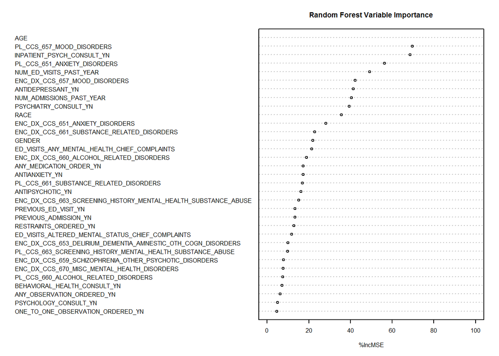

```r
#rf$importance
rf.pred <- predict(rf, rf_data, type = "prob")
rf.pred.pos <- rf.pred[ , 2]

#K-Fold Cross Validation
N = nrow(rf_data)
K = 10
set.seed(1234)
s = sample(1:K, size = N, replace = T)
pred.outputs.rf <- vector(mode = "numeric", length = N)
obs.outputs <- vector(mode = "numeric", length = N)
offset <- 0
for(i in 1:K){
    train <- filter(rf_data, s != i)
    test <- filter(rf_data, s == i)
    obs.outputs[1:length(s[s == i]) + offset] <- test$screening_outcome

    #RF train/test
    rf <- randomForest(screening_outcome ~ ., data = train, ntree = 100)
    rf.pred.curr <- predict(rf, newdata = test, type = "prob")
    pred.outputs.rf[1:length(s[s == i]) + offset] <- rf.pred.curr[ , 2]

    offset <- offset + length(s[s == i])
}

# Variable Importance Plot
impToPlot <- importance(rf, scale=FALSE)
dotchart(sort(impToPlot[,1]), xlim=c(0,100), xlab="%IncMSE", cex=0.5, main='Random Forest Variable Importance')
```

```r
# ROC Curves for RandomForest
par(pty = "s")
roc(obs.outputs, pred.outputs.rf, ci = TRUE)
```

```
##
## Call:
## roc.default(response = obs.outputs, predictor = pred.outputs.rf,     ci = TRUE)
##
## Data: pred.outputs.rf in 1873 controls (obs.outputs 1) < 1280 cases (obs.outputs 2).
## Area under the curve: 0.7971
## 95% CI: 0.7807-0.8135 (DeLong)
```

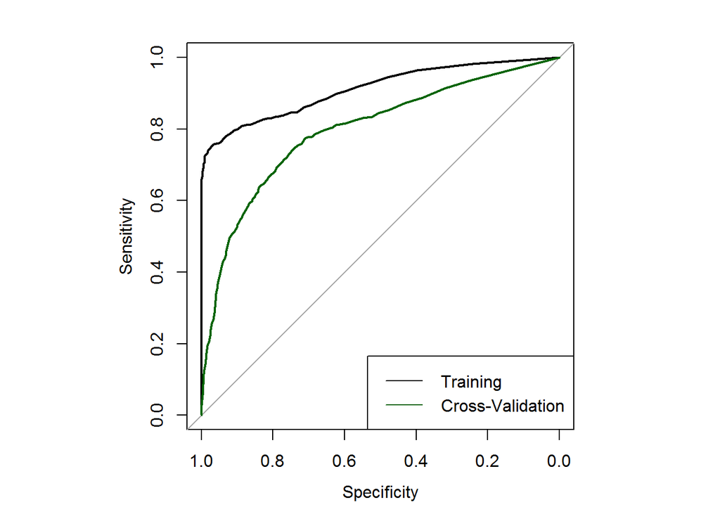

```r
plot.roc(rf_data$screening_outcome, rf.pred.pos)
plot.roc(obs.outputs, pred.outputs.rf, ci = TRUE, col = "darkgreen", add = TRUE)
legend("bottomright", legend = c("Training", "Cross-Validation"), col = c("black", "darkgreen"), lwd = 1)
```

## Exploratory Analysis using Clinical Notes

> Free text data stored within clinical notes likely includes important details for a patient that could not be identified using discrete data elements alone. This section involves randomly sampling 500 cases and 500 controls. The encounter IDs for these patients are used to query clinical notes from the inpatient, ED, and outpatient settings in the 6 months prior to admission (including the first day of the admission). Initial visualizations of the text using barcharts and word clouds included terms likely related to medications, such as “mg,” “oral,” and “tablet.”

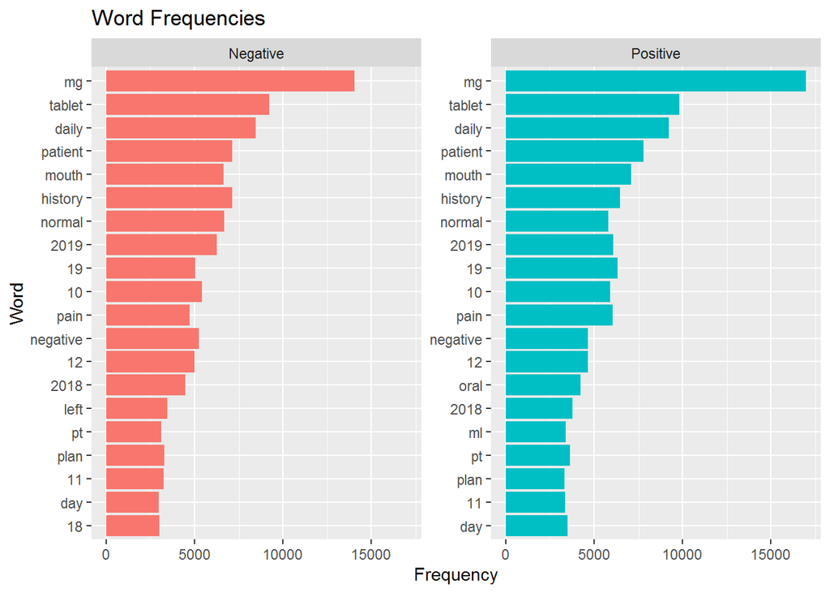

```r
# Text Analysis
library(tidytext)
library(wordcloud)

# Randomly select 500 Cases and 500 Controls to create sample of notes
set.seed(123)

pos_csn_list <- clarity %>% dplyr::select(PAT_ENC_CSN_ID,RANDOM_ID,RANDOM_ENC_ID) %>%
  inner_join(dplyr::select(final_cohort,RANDOM_ID,RANDOM_ENC_ID,screening_outcome),by="RANDOM_ENC_ID") %>%
  filter(screening_outcome=="Positive") %>% dplyr::select(PAT_ENC_CSN_ID,RANDOM_ENC_ID,screening_outcome) %>%
  sample_n(size=500, replace = FALSE)

neg_csn_list <- clarity %>% dplyr::select(PAT_ENC_CSN_ID,RANDOM_ID,RANDOM_ENC_ID) %>%
  inner_join(dplyr::select(final_cohort,RANDOM_ID,RANDOM_ENC_ID,screening_outcome),by="RANDOM_ENC_ID") %>%
  filter(screening_outcome=="Negative") %>% dplyr::select(PAT_ENC_CSN_ID,RANDOM_ENC_ID,screening_outcome) %>%
  sample_n(size=500, replace = FALSE)

sample_csn_list <- rbind(pos_csn_list,neg_csn_list)

write.csv(sample_csn_list,file="U:/MEND/sample_csn_for_notes.csv",row.names=FALSE)

patient_notes <- read_xlsx("U:/MEND/Sample_Patient_Notes_13Dec2019.xlsx",col_names=TRUE)

custom_stop_words <- tribble(
  ~word, ~lexicon,
  "æ¼ã¸²","CUSTOM",
  "1","CUSTOM",
  "2","CUSTOM",
  "3","CUSTOM",
  "4","CUSTOM",
  "5","CUSTOM",
  "6","CUSTOM",
  "7","CUSTOM",
  "8","CUSTOM",
  "9","CUSTOM"
) %>% rbind(stop_words)

word_counts <- patient_notes %>%
  # Tokenize text
  unnest_tokens(word,note_text) %>%
  # Remove Stopwords
  anti_join(custom_stop_words) %>%
  # Summarize
  count(word, screening_outcome) %>%
  group_by(screening_outcome) %>%
  top_n(20, n) %>%
  ungroup() %>%
  mutate(word2 = fct_reorder(word,n))

word_counts %>%
  ggplot(aes(x=reorder(word2,n),y=n,fill=screening_outcome)) +
  geom_col(show.legend=FALSE) +
  facet_wrap(~ screening_outcome, scales="free_y") +
  coord_flip() +
  ggtitle("Word Frequencies") +
  xlab("Word") +
  ylab("Frequency")
```

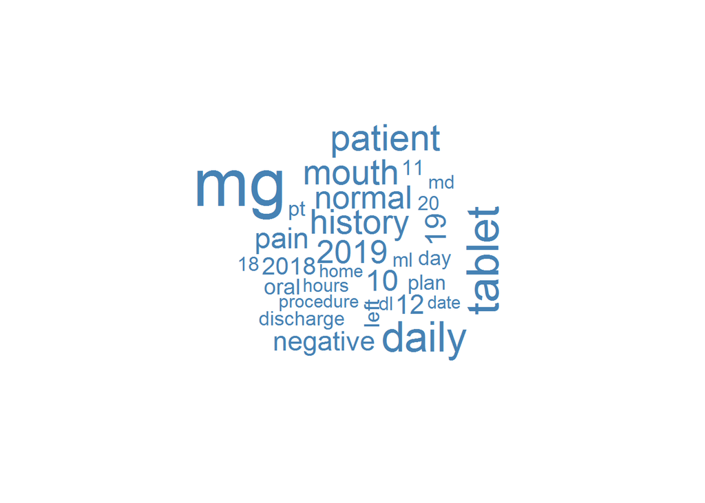

```r
# Word Cloud
word_counts <- patient_notes %>%
  # Tokenize text
  unnest_tokens(word,note_text) %>%
  # Remove Stopwords
  anti_join(custom_stop_words) %>%
  # Summarize
  count(word) %>%
  top_n(100)

wordcloud(
  words = word_counts$word,
  freq = word_counts$n,
  max.words = 30,
  colors = "steelblue"
)
```

> The comparison cloud contrasting the terms found in each group displayed the words “anxiety,” “disorder,” and “pain.” Medication-related terms appeared to be more common among those who were screened as eligible.

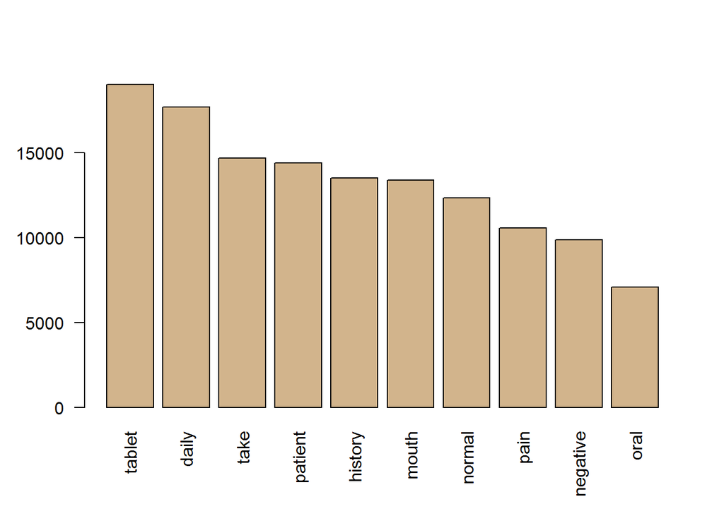

```r
library(tm)
library(plotrix)

df_source <- patient_notes %>%
  dplyr::select(RANDOM_ENC_ID, note_text, screening_outcome) %>%
  rename(doc_id = RANDOM_ENC_ID, text = note_text) %>% DataframeSource()

df_corpus <- VCorpus(df_source)

clean_text <- function(text){
  # Remove Punctuation
  text <- tm_map(text,removePunctuation)
  # Transform to lower case
  text <- tm_map(text,content_transformer(tolower))
  # Remove Stop Words
  text <- tm_map(text,removeWords, c(stopwords("en"), "æ¼ã¸²"))
  # Remove Numbers
  text <- tm_map(text, removeNumbers)
  # Strip whitespace
  text <- tm_map(text,stripWhitespace)
  return(text)
}

clean_corpus <- clean_text(df_corpus)

# Create a Term Document Matrix (TDM)
notes_tdm <- TermDocumentMatrix(clean_corpus) %>% as.matrix()

term_freq <- rowSums(notes_tdm)
term_freq <- sort(term_freq,decreasing=TRUE)

barplot(term_freq[1:10],col="tan",las=2)
```

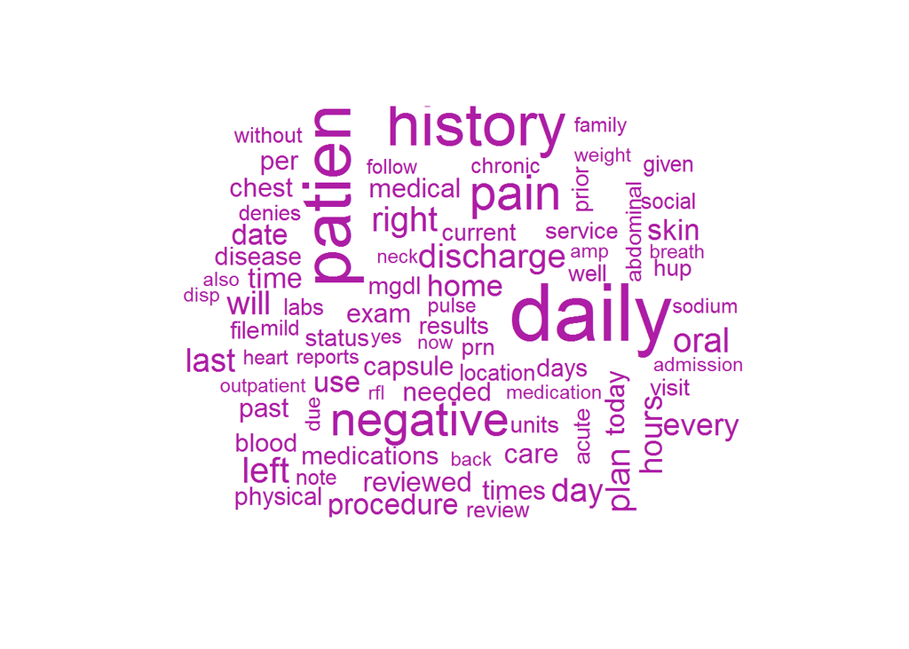

```r
# Separate Positive and Negative Cases
positive_text <- patient_notes %>% filter(screening_outcome=="Positive") %>% dplyr::select(note_text)
positive_text <- paste(positive_text,collapse=" ")

negative_text <- patient_notes %>% filter(screening_outcome=="Negative") %>% dplyr::select(note_text)
negative_text <- paste(negative_text,collapse=" ")

all_text <- c(positive_text,negative_text)
all_text <- VectorSource(all_text)
all_corpus <- VCorpus(all_text)

all_clean <- clean_text(all_corpus)

all_tdm <- TermDocumentMatrix(all_clean) %>% as.matrix()

colnames(all_tdm) <- c("Positive","Negative")

# Commonality Wordcloud
commonality.cloud(all_tdm,max.words=90,colors="#AD1DA5")
```

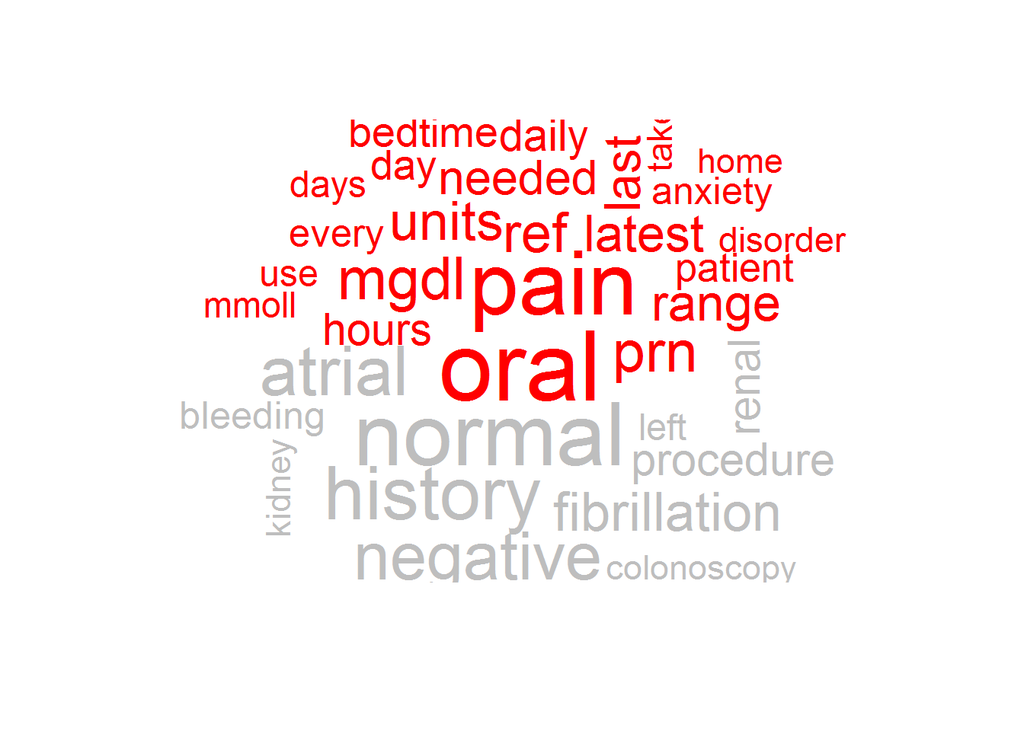

```r
# Comparison Cloud
comparison.cloud(all_tdm,colors=c('red','grey'),max.words=35)
```

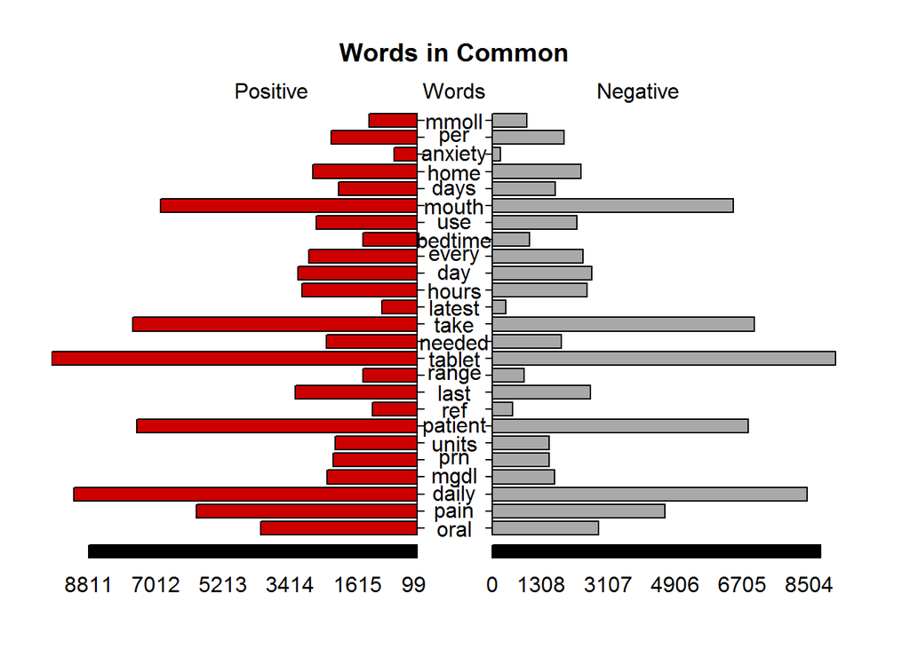

```
## [1] 5.1 4.1 4.1 2.1
```

```r
# Pyramid Plot
top_25_words <- all_tdm %>% as_data_frame(rownames="word") %>% filter(Positive>0 & Negative>0) %>%
  mutate(difference = Positive-Negative) %>%
  top_n(25, wt=difference) %>%
  arrange(desc(difference))

pyramid.plot(
  # Positive counts
  top_25_words$Positive,
  # Negative counts
  top_25_words$Negative,
  # Labels
  labels = top_25_words$word,
  top.labels = c("Positive","Words","Negative"),
  main = "Words in Common",
  unit = NULL,
  gap = 1000,
  space = 0.2,
  lxcol = "red3",
  rxcol = "darkgrey"
)
```

## Modeling Text Data

```r
library(e1071)
library(caret)
library(klaR)

# Create a Document Term Matrix (DTM) with TF-IDF
dtm <- DocumentTermMatrix(clean_corpus, control = list(weighting=weightTfIdf)) %>% removeSparseTerms(0.90)

analytic_set <- cbind(patient_notes,as.matrix(dtm))
analytic_set <- analytic_set %>%
  dplyr::select(-RANDOM_ENC_ID,-PAT_ENC_CSN_ID,-note_text) %>%
  mutate(screening_outcome=factor(if_else(screening_outcome=="Positive",1,0),levels=c(0,1),labels=c("Negative","Positive")))

# Split Data
train_index <- createDataPartition(analytic_set$screening_outcome, p=0.80, list=FALSE)
nb_train <- analytic_set[train_index,]
nb_test <- analytic_set[-train_index,]

# create response and feature data
features <- setdiff(names(nb_train), "screening_outcome")
x <- nb_train[, features]
y <- nb_train$screening_outcome

# 10-fold cross validation procedure
train_control <- trainControl(
  method = "cv",
  number = 10
  )

# Train model
naivebayes_model <- train(
  x = x,
  y = y,
  method = "nb",
  trControl = train_control
  )

# Results
confusionMatrix(naivebayes_model)
```

```
## Cross-Validated (10 fold) Confusion Matrix
##
## (entries are percentual average cell counts across resamples)
##
##           Reference
## Prediction Negative Positive
##   Negative     21.4     14.9
##   Positive     27.5     36.2
##
##  Accuracy (average) : 0.5755
```

```r
# Testing
nb_prediction <- predict(naivebayes_model, newdata = nb_test[,features], type='raw')

# Naive Bayes ROC
roc(nb_test$screening_outcome, factor(nb_prediction,ordered=TRUE), ci = TRUE)
```

```
##
## Call:
## roc.default(response = nb_test$screening_outcome, predictor = factor(nb_prediction,     ordered = TRUE), ci = TRUE)
##
## Data: factor(nb_prediction, ordered = TRUE) in 73 controls (nb_test$screening_outcome Negative) < 77 cases (nb_test$screening_outcome Positive).
## Area under the curve: 0.5424
## 95% CI: 0.4663-0.6186 (DeLong)
```

```r
# Support Vector Machine
svm_model <- svm(screening_outcome ~ ., data = analytic_set, scale = TRUE, kernel = "radial", probability = TRUE)
svm.pred <- predict(svm_model, analytic_set, probability = TRUE)
svm.pred.pos <- attr(svm.pred, "probabilities")[ , 1]

# K-Fold Cross Validation
N = nrow(analytic_set)
K = 10
set.seed(333)
s = sample(1:K, size = N, replace = T)
pred.outputs.svm <- vector(mode = "numeric", length = N)
obs.outputs <- vector(mode = "numeric", length = N)
offset <- 0
for(i in 1:K){
    train <- filter(analytic_set, s != i)
    test <- filter(analytic_set, s == i)
    obs.outputs[1:length(s[s == i]) + offset] <- test$screening_outcome

    #SVM train/test
    svm.m <- svm(screening_outcome ~ ., data = train, scale = TRUE, kernel = "radial", probability = TRUE)
    svm.pred.curr <- predict(svm.m, test, probability = TRUE)
    pred.outputs.svm[1:length(s[s == i]) + offset] <- attr(svm.pred.curr, "probabilities")[ , 1]

    offset <- offset + length(s[s == i])
}

# ROC Curves for SVM
par(pty = "s")
roc(obs.outputs, pred.outputs.svm, ci = TRUE)
```

```
##
## Call:
## roc.default(response = obs.outputs, predictor = pred.outputs.svm,     ci = TRUE)
##
## Data: pred.outputs.svm in 368 controls (obs.outputs 1) < 385 cases (obs.outputs 2).
## Area under the curve: 0.639
## 95% CI: 0.5999-0.6781 (DeLong)
```

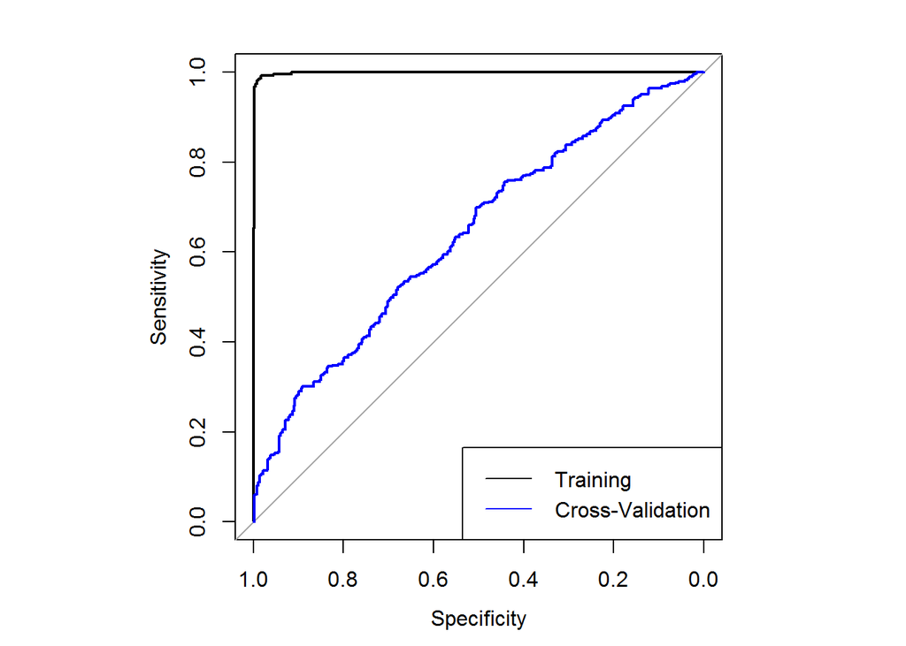

```r
plot.roc(analytic_set$screening_outcome, svm.pred.pos)
plot.roc(obs.outputs, pred.outputs.svm, ci = TRUE, col = "blue", add = TRUE)
legend("bottomright", legend = c("Training", "Cross-Validation"), col = c("black", "blue"), lwd = 1)
```

## Evaluating the Impact of the Program

> This section evaluates if there are any differences in who receives the MEND intervention. Although those receiving the intervention were significantly younger (mean 53 vs 55.6 years), this was not a clinically meaningful difference. There were no significant differences by race or gender.

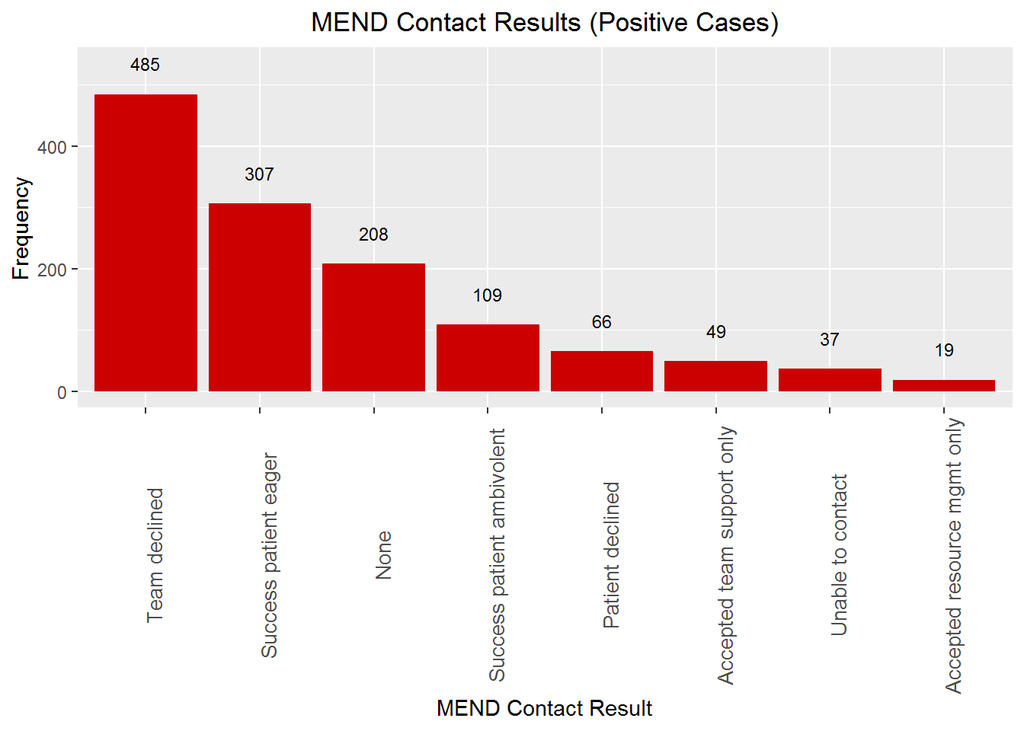

```r
# Show bar plot MEND Contact Results Among Those Screened Positive
final_cohort %>% filter(screening_outcome=="Positive") %>% group_by(mend_contact_result) %>% count() %>%
  ggplot(aes(x=reorder(mend_contact_result,-n),n)) +
  geom_bar(stat='identity',fill='red3') +
  theme(axis.text.x = element_text(angle = 90,size=10),plot.title=element_text(hjust=0.5)) +
  ggtitle("MEND Contact Results (Positive Cases)") +
  xlab("MEND Contact Result") +
  ylab("Frequency") +
  scale_fill_manual(values=c("#999999", "red3")) +
  geom_text(aes(x = mend_contact_result, y = n+50, label = n), colour="black", size = 3)
```

```r
outcome_eval <- final_cohort %>% filter(screening_outcome=="Positive") %>%
  mutate(Received_Intervention_YN = factor(if_else(mend_contact_result %in%
                                                     c("Accepted resource mgmt only","Accepted team support only",
                                                       "Success patient ambivolent","Success patient eager"),1,0),
                                           levels=c(1,0),labels=c("Yes","No")))

# Categorical Variables
outcome_eval %>% group_by(Received_Intervention_YN,RACE) %>%
  summarize(Freq=n()) %>%
  group_by(RACE) %>%
  mutate(Prop = Freq/sum(Freq), N_Proportion = paste(Freq," (", round(Freq / sum(Freq)*100,2),")",sep='')) %>%
  arrange(desc(Received_Intervention_YN),RACE) %>% kable()
```

| Received_Intervention_YN | RACE | Freq | Prop | N_Proportion |
| --- | --- | --- | --- | --- |
| No | Asian | 16 | 0.7272727 | 16 (72.73) |
| No | Black | 379 | 0.6295681 | 379 (62.96) |
| No | Other | 10 | 0.4347826 | 10 (43.48) |
| No | Patient Declined | 2 | 1.0000000 | 2 (100) |
| No | Unknown | 16 | 0.5714286 | 16 (57.14) |
| No | White | 373 | 0.6185738 | 373 (61.86) |
| Yes | Asian | 6 | 0.2727273 | 6 (27.27) |
| Yes | Black | 223 | 0.3704319 | 223 (37.04) |
| Yes | Other | 13 | 0.5652174 | 13 (56.52) |
| Yes | Unknown | 12 | 0.4285714 | 12 (42.86) |
| Yes | White | 230 | 0.3814262 | 230 (38.14) |

```r
fisher.test(table(outcome_eval$Received_Intervention_YN,outcome_eval$RACE))
```

```
##
##  Fisher's Exact Test for Count Data
##
## data:  table(outcome_eval$Received_Intervention_YN, outcome_eval$RACE)
## p-value = 0.3232
## alternative hypothesis: two.sided
```

```r
outcome_eval %>% group_by(Received_Intervention_YN,GENDER) %>%
  summarize(Freq=n()) %>%
  group_by(GENDER) %>%
  mutate(Prop = Freq/sum(Freq), N_Proportion = paste(Freq," (", round(Freq / sum(Freq)*100,2),")",sep='')) %>%
  arrange(desc(Received_Intervention_YN),GENDER) %>% kable()
```

| Received_Intervention_YN | GENDER | Freq | Prop | N_Proportion |
| --- | --- | --- | --- | --- |
| No | Female | 424 | 0.6162791 | 424 (61.63) |
| No | Male | 372 | 0.6283784 | 372 (62.84) |
| Yes | Female | 264 | 0.3837209 | 264 (38.37) |
| Yes | Male | 220 | 0.3716216 | 220 (37.16) |

```r
chisq.test(table(outcome_eval$Received_Intervention_YN,outcome_eval$GENDER))
```

```
##
##  Pearson's Chi-squared test with Yates' continuity correction
##
## data:  table(outcome_eval$Received_Intervention_YN, outcome_eval$GENDER)
## X-squared = 0.14999, df = 1, p-value = 0.6985
```

```r
# Continous Variables
outcome_eval %>% group_by(Received_Intervention_YN) %>% summarize(N=n(), AvgAge=mean(AGE), SdAge=sd(AGE), MedianAge=median(AGE),
Q1AGe=quantile(AGE,0.25), Q3Age=quantile(AGE,0.75), MinAge=min(AGE),MaxAge=max(AGE)) %>% kable()
```

| Received_Intervention_YN | N | AvgAge | SdAge | MedianAge | Q1AGe | Q3Age | MinAge | MaxAge |
| --- | --- | --- | --- | --- | --- | --- | --- | --- |
| Yes | 484 | 53.00413 | 18.22893 | 55 | 37 | 67 | 18 | 94 |
| No | 796 | 55.57161 | 17.25418 | 57 | 43 | 68 | 19 | 98 |